# Ciprofloxacin resistance in Klebsiella pneumoniae

Kara Tsang, Kat Holt

Last compiled on 19/06/26

# load data

```r
geno <- read_delim("tables/TableS2_genotypes.tsv")
pheno <- read_delim("tables/TableS3_phenotypes_metadata.tsv")
cipro_antibiogram <- full_join(geno,pheno) %>%
  mutate(SRnwt = if_else(Resistance.phenotype=="I", "NWT", Resistance.phenotype)) %>%
  mutate(SRnwt = factor(SRnwt, levels=c("S","NWT","R")))
```

## set colours

```r
wt_colours <- c(`non-wt (I/R)`="IndianRed", `wt (S)`= "LightBlue")
res_colours <- c("I"="grey", "R"="IndianRed", "S"="LightBlue", "NWT"="grey")
```

## long form, one row per strain/determinant combination

```r
cipro_res_mech <- cipro_antibiogram %>%
  # mutate(Aac6_gene=if_else(aac6 == 1, "aac(6ʹ)-Ib-cr", "-")) %>%
  pivot_longer(c(Flq_mutations,Flq_acquired, aac6_allele), names_to = "marker.type",
               values_to = "marker") %>%
  separate_longer_delim(cols=marker, delim=";")
```

# Numbers reported in text - para 3

```r
# effect of ParC when added to GyrA-83 background (absence of any genes or GyrA-87)

# MIC data
QRDR_MIC_GyrA83background_noGenes_dat <- cipro_antibiogram %>%
    filter(aac6==0 & acquired_genes==0 & `GyrA-83`==1 & `GyrA-87`==0) %>%
  filter(grepl('MIC.*$', Laboratory.Typing.Method)) %>%
  select(Measurement, Resistance.phenotype, resistant, nonWT_binary, ParC_mutations, `ParC-80`, `ParC-84`)

wilcox.test(log2(as.numeric(Measurement)) ~ ParC_mutations, data=QRDR_MIC_GyrA83background_noGenes_dat)
```

```
##
##  Wilcoxon rank sum test with continuity correction
##
## data:  log2(as.numeric(Measurement)) by ParC_mutations
## W = 13120, p-value = 0.001189
## alternative hypothesis: true location shift is not equal to 0
```

```r
summary(lm(log2(as.numeric(Measurement)) ~ ParC_mutations, data=QRDR_MIC_GyrA83background_noGenes_dat))
```

```
##
## Call:
## lm(formula = log2(as.numeric(Measurement)) ~ ParC_mutations,
##     data = QRDR_MIC_GyrA83background_noGenes_dat)
##
## Residuals:
##     Min      1Q  Median      3Q     Max
## -3.0915 -0.0915 -0.0915  0.2586  7.9085
##
## Coefficients:
##                Estimate Std. Error t value Pr(>|t|)
## (Intercept)      0.7414     0.1394   5.318 1.45e-07 ***
## ParC_mutations   0.3501     0.1461   2.397   0.0168 *
## ---
## Signif. codes:  0 '***' 0.001 '**' 0.01 '*' 0.05 '.' 0.1 ' ' 1
##
## Residual standard error: 1.062 on 646 degrees of freedom
## Multiple R-squared:  0.008813,   Adjusted R-squared:  0.007279
## F-statistic: 5.744 on 1 and 646 DF,  p-value: 0.01683
```

```r
summary(as.numeric(QRDR_MIC_GyrA83background_noGenes_dat$Measurement)[QRDR_MIC_GyrA83background_noGenes_dat$`ParC_mutations`==1])
```

```
##    Min. 1st Qu.  Median    Mean 3rd Qu.    Max.
##   0.250   2.000   2.000   4.692   2.000 512.000
```

```r
summary(as.numeric(QRDR_MIC_GyrA83background_noGenes_dat$Measurement)[QRDR_MIC_GyrA83background_noGenes_dat$`ParC_mutations`==0])
```

```
##    Min. 1st Qu.  Median    Mean 3rd Qu.    Max.
##   0.250   1.000   1.000   2.901   4.000  16.000
```

```r
# disk diffusion
QRDR_DD_GyrA83background_noGenes_dat <- cipro_antibiogram %>%
  filter(aac6==0 & acquired_genes==0 & `GyrA-83`==1 & `GyrA-87`==0) %>%
  filter(Laboratory.Typing.Method=="Disk diffusion") %>%
  select(Measurement, Resistance.phenotype, resistant, nonWT_binary, ParC_mutations, `ParC-80`, `ParC-84`)

wilcox.test(as.numeric(Measurement) ~ ParC_mutations, data=QRDR_DD_GyrA83background_noGenes_dat)
```

```
##
##  Wilcoxon rank sum test with continuity correction
##
## data:  as.numeric(Measurement) by ParC_mutations
## W = 1112.5, p-value = 5.475e-09
## alternative hypothesis: true location shift is not equal to 0
```

```r
summary(lm(as.numeric(Measurement) ~ ParC_mutations, data=QRDR_DD_GyrA83background_noGenes_dat))
```

```
##
## Call:
## lm(formula = as.numeric(Measurement) ~ ParC_mutations, data = QRDR_DD_GyrA83background_noGenes_dat)
##
## Residuals:
##    Min     1Q Median     3Q    Max
## -7.870 -3.585 -1.727  3.202 20.415
##
## Coefficients:
##                Estimate Std. Error t value Pr(>|t|)
## (Intercept)      18.870      1.006   18.76  < 2e-16 ***
## ParC_mutations   -9.285      1.204   -7.71 4.58e-11 ***
## ---
## Signif. codes:  0 '***' 0.001 '**' 0.01 '*' 0.05 '.' 0.1 ' ' 1
##
## Residual standard error: 4.823 on 74 degrees of freedom
## Multiple R-squared:  0.4454, Adjusted R-squared:  0.4379
## F-statistic: 59.44 on 1 and 74 DF,  p-value: 4.582e-11
```

```r
summary(as.numeric(QRDR_DD_GyrA83background_noGenes_dat$Measurement)[QRDR_DD_GyrA83background_noGenes_dat$ParC_mutations==1])
```

```
##    Min. 1st Qu.  Median    Mean 3rd Qu.    Max.
##   6.000   6.000   6.000   9.585  13.000  30.000
```

```r
summary(as.numeric(QRDR_DD_GyrA83background_noGenes_dat$Measurement)[QRDR_DD_GyrA83background_noGenes_dat$ParC_mutations==0])
```

```
##    Min. 1st Qu.  Median    Mean 3rd Qu.    Max.
##   11.00   16.00   20.00   18.87   22.00   25.00
```

```r
# test categorial phenotypes

# all genomes with no acquired genes (MIC/DD)
QRDR_noGenes_dat <- cipro_antibiogram %>%
    filter(aac6==0 & acquired_genes==0) %>%
  select(Measurement, Resistance.phenotype, resistant, nonWT_binary, QRDR_mutations) %>%
  mutate(qrdr_bin=if_else(QRDR_mutations==0, 0, 1))

# nonWT vs presence/absence
fisher.test(table(QRDR_noGenes_dat$nonWT_binary, QRDR_noGenes_dat$qrdr_bin))
```

```
##
##  Fisher's Exact Test for Count Data
##
## data:  table(QRDR_noGenes_dat$nonWT_binary, QRDR_noGenes_dat$qrdr_bin)
## p-value < 2.2e-16
## alternative hypothesis: true odds ratio is not equal to 1
## 95 percent confidence interval:
##   525.1282 1263.1985
## sample estimates:
## odds ratio
##   825.4557
```

```r
# resistance vs presence/absence
fisher.test(table(QRDR_noGenes_dat$resistant, QRDR_noGenes_dat$qrdr_bin))
```

```
##
##  Fisher's Exact Test for Count Data
##
## data:  table(QRDR_noGenes_dat$resistant, QRDR_noGenes_dat$qrdr_bin)
## p-value < 2.2e-16
## alternative hypothesis: true odds ratio is not equal to 1
## 95 percent confidence interval:
##  1050.256 2411.696
## sample estimates:
## odds ratio
##   1519.011
```

# Numbers reported in text - para 4

## effect of presence/absence of any QRDR, in absence of any acquired genes

```r
# total strains without PMQR or aac6
nrow(QRDR_noGenes_dat)
```

```
## [1] 7454
```

```r
# presence of QRDR vs MIC
QRDR_MIC_noGenes_dat <- cipro_antibiogram %>%
  filter(grepl('MIC.*$', Laboratory.Typing.Method)) %>%
    filter(aac6==0 & acquired_genes==0) %>%
  select(Measurement, Resistance.phenotype, resistant, nonWT_binary, QRDR_mutations, `GyrA-83`, `ParC-80`) %>%
  mutate(qrdr_bin=if_else(QRDR_mutations==0, 0, 1))

wilcox.test(log2(as.numeric(Measurement)) ~ qrdr_bin, data=QRDR_MIC_noGenes_dat)
```

```
##
##  Wilcoxon rank sum test with continuity correction
##
## data:  log2(as.numeric(Measurement)) by qrdr_bin
## W = 98114, p-value < 2.2e-16
## alternative hypothesis: true location shift is not equal to 0
```

```r
summary(lm(log2(as.numeric(Measurement)) ~ qrdr_bin, data=QRDR_MIC_noGenes_dat))
```

```
##
## Call:
## lm(formula = log2(as.numeric(Measurement)) ~ qrdr_bin, data = QRDR_MIC_noGenes_dat)
##
## Residuals:
##     Min      1Q  Median      3Q     Max
## -3.1815 -0.1815 -0.0414 -0.0414  7.9586
##
## Coefficients:
##             Estimate Std. Error t value Pr(>|t|)
## (Intercept) -1.95856    0.01638  -119.6   <2e-16 ***
## qrdr_bin     3.14005    0.02795   112.3   <2e-16 ***
## ---
## Signif. codes:  0 '***' 0.001 '**' 0.01 '*' 0.05 '.' 0.1 ' ' 1
##
## Residual standard error: 0.9208 on 4811 degrees of freedom
## Multiple R-squared:  0.724,  Adjusted R-squared:  0.724
## F-statistic: 1.262e+04 on 1 and 4811 DF,  p-value: < 2.2e-16
```

```r
summary(as.numeric(QRDR_MIC_noGenes_dat$Measurement)[QRDR_MIC_noGenes_dat$qrdr_bin==1])
```

```
##    Min. 1st Qu.  Median    Mean 3rd Qu.    Max.
##   0.250   2.000   2.000   5.539   2.000 512.000
```

```r
summary(as.numeric(QRDR_MIC_noGenes_dat$Measurement)[QRDR_MIC_noGenes_dat$qrdr_bin==0])
```

```
##    Min. 1st Qu.  Median    Mean 3rd Qu.    Max.
##  0.0300  0.2500  0.2500  0.3421  0.2500 64.0000
```

```r
# presence of QRDR vs DD zone
QRDR_DD_noGenes_dat <- cipro_antibiogram %>%
    filter(aac6==0 & acquired_genes==0) %>%
    filter(Laboratory.Typing.Method=="Disk diffusion") %>%
  select(Measurement, Resistance.phenotype, resistant, nonWT_binary, QRDR_mutations) %>%
  mutate(qrdr_bin=if_else(QRDR_mutations==0, 0, 1))

wilcox.test(as.numeric(Measurement) ~ qrdr_bin, data=QRDR_DD_noGenes_dat)
```

```
##
##  Wilcoxon rank sum test with continuity correction
##
## data:  as.numeric(Measurement) by qrdr_bin
## W = 320646, p-value < 2.2e-16
## alternative hypothesis: true location shift is not equal to 0
```

```r
summary(lm(as.numeric(Measurement) ~ qrdr_bin, data=QRDR_DD_noGenes_dat))
```

```
##
## Call:
## lm(formula = as.numeric(Measurement) ~ qrdr_bin, data = QRDR_DD_noGenes_dat)
##
## Residuals:
##      Min       1Q   Median       3Q      Max
## -22.6659  -1.6659   0.3341   1.3341  18.1154
##
## Coefficients:
##              Estimate Std. Error t value Pr(>|t|)
## (Intercept)  28.66587    0.06349  451.51   <2e-16 ***
## qrdr_bin    -16.78125    0.28616  -58.64   <2e-16 ***
## ---
## Signif. codes:  0 '***' 0.001 '**' 0.01 '*' 0.05 '.' 0.1 ' ' 1
##
## Residual standard error: 3.181 on 2639 degrees of freedom
## Multiple R-squared:  0.5658, Adjusted R-squared:  0.5656
## F-statistic:  3439 on 1 and 2639 DF,  p-value: < 2.2e-16
```

```r
summary(as.numeric(QRDR_DD_noGenes_dat$Measurement)[QRDR_DD_noGenes_dat$qrdr_bin==1])
```

```
##    Min. 1st Qu.  Median    Mean 3rd Qu.    Max.
##    6.00    6.00    9.00   11.88   17.00   30.00
```

```r
summary(as.numeric(QRDR_DD_noGenes_dat$Measurement)[QRDR_DD_noGenes_dat$qrdr_bin==0])
```

```
##    Min. 1st Qu.  Median    Mean 3rd Qu.    Max.
##    6.00   27.00   29.00   28.67   30.00   44.00
```

```r
# presence of QRDR vs nonWT
fisher.test(table(QRDR_noGenes_dat$nonWT_binary, QRDR_noGenes_dat$qrdr_bin))
```

```
##
##  Fisher's Exact Test for Count Data
##
## data:  table(QRDR_noGenes_dat$nonWT_binary, QRDR_noGenes_dat$qrdr_bin)
## p-value < 2.2e-16
## alternative hypothesis: true odds ratio is not equal to 1
## 95 percent confidence interval:
##   525.1282 1263.1985
## sample estimates:
## odds ratio
##   825.4557
```

```r
# presence of QRDR vs R
fisher.test(table(QRDR_noGenes_dat$resistant, QRDR_noGenes_dat$qrdr_bin))
```

```
##
##  Fisher's Exact Test for Count Data
##
## data:  table(QRDR_noGenes_dat$resistant, QRDR_noGenes_dat$qrdr_bin)
## p-value < 2.2e-16
## alternative hypothesis: true odds ratio is not equal to 1
## 95 percent confidence interval:
##  1050.256 2411.696
## sample estimates:
## odds ratio
##   1519.011
```

## effect of number of QRDR mutations, in absence of any acquired genes

```r
# MIC vs QRDR count
QRDR_MIC_noGenes_dat <- QRDR_MIC_noGenes_dat %>%
  mutate(QRDR_0_1_2 = if_else(QRDR_mutations>2, 2, QRDR_mutations)) %>%
  mutate(QRDR_0_1_2_3 = if_else(QRDR_mutations>3, 3, QRDR_mutations)) %>%
  mutate(QRDR_1_2 = if_else(QRDR_0_1_2==0, NA, QRDR_0_1_2)) %>%
  mutate(QRDR_2_3 = if_else(QRDR_0_1_2<2, NA, QRDR_0_1_2_3))

# median MICs, grouped by QRDR count
summary(as.numeric(QRDR_MIC_noGenes_dat$Measurement)[QRDR_MIC_noGenes_dat$QRDR_mutations==0])
```

```
##    Min. 1st Qu.  Median    Mean 3rd Qu.    Max.
##  0.0300  0.2500  0.2500  0.3421  0.2500 64.0000
```

```r
summary(as.numeric(QRDR_MIC_noGenes_dat$Measurement)[QRDR_MIC_noGenes_dat$QRDR_mutations==1])
```

```
##    Min. 1st Qu.  Median    Mean 3rd Qu.    Max.
##   0.250   1.000   1.000   2.597   2.000  16.000
```

```r
summary(as.numeric(QRDR_MIC_noGenes_dat$Measurement)[QRDR_MIC_noGenes_dat$QRDR_mutations>2])
```

```
##    Min. 1st Qu.  Median    Mean 3rd Qu.    Max.
##   0.250   2.000   2.000   6.257   2.000 512.000
```

```r
# test for difference in MIC with QRDR count
summary(lm(log2(as.numeric(Measurement)) ~ factor(QRDR_0_1_2), data=QRDR_MIC_noGenes_dat))
```

```
##
## Call:
## lm(formula = log2(as.numeric(Measurement)) ~ factor(QRDR_0_1_2),
##     data = QRDR_MIC_noGenes_dat)
##
## Residuals:
##     Min      1Q  Median      3Q     Max
## -3.2087 -0.2087 -0.0414 -0.0414  7.9586
##
## Coefficients:
##                     Estimate Std. Error t value Pr(>|t|)
## (Intercept)         -1.95856    0.01633 -119.95   <2e-16 ***
## factor(QRDR_0_1_2)1  2.54190    0.10939   23.24   <2e-16 ***
## factor(QRDR_0_1_2)2  3.16729    0.02827  112.02   <2e-16 ***
## ---
## Signif. codes:  0 '***' 0.001 '**' 0.01 '*' 0.05 '.' 0.1 ' ' 1
##
## Residual standard error: 0.9178 on 4810 degrees of freedom
## Multiple R-squared:  0.7258, Adjusted R-squared:  0.7257
## F-statistic:  6367 on 2 and 4810 DF,  p-value: < 2.2e-16
```

```r
summary(lm(log2(as.numeric(Measurement)) ~ QRDR_mutations, data=QRDR_MIC_noGenes_dat))
```

```
##
## Call:
## lm(formula = log2(as.numeric(Measurement)) ~ QRDR_mutations,
##     data = QRDR_MIC_noGenes_dat)
##
## Residuals:
##     Min      1Q  Median      3Q     Max
## -3.5744 -0.1039 -0.1039 -0.1039  8.5824
##
## Coefficients:
##                Estimate Std. Error t value Pr(>|t|)
## (Intercept)    -1.89613    0.01706  -111.2   <2e-16 ***
## QRDR_mutations  1.15685    0.01110   104.2   <2e-16 ***
## ---
## Signif. codes:  0 '***' 0.001 '**' 0.01 '*' 0.05 '.' 0.1 ' ' 1
##
## Residual standard error: 0.971 on 4811 degrees of freedom
## Multiple R-squared:  0.6931, Adjusted R-squared:  0.6931
## F-statistic: 1.087e+04 on 1 and 4811 DF,  p-value: < 2.2e-16
```

```r
# DD vs QRDR count
QRDR_DD_noGenes_dat <- QRDR_DD_noGenes_dat %>%
  mutate(QRDR_0_1_2 = if_else(QRDR_mutations>2, 2, QRDR_mutations)) %>%
  mutate(QRDR_0_1_2_3 = if_else(QRDR_mutations>3, 3, QRDR_mutations)) %>%
  mutate(QRDR_1_2 = if_else(QRDR_0_1_2==0, NA, QRDR_0_1_2)) %>%
  mutate(QRDR_2_3 = if_else(QRDR_0_1_2<2, NA, QRDR_0_1_2_3))

# median DD zones, grouped by QRDR count
summary(as.numeric(QRDR_DD_noGenes_dat$Measurement)[QRDR_DD_noGenes_dat$QRDR_mutations==0])
```

```
##    Min. 1st Qu.  Median    Mean 3rd Qu.    Max.
##    6.00   27.00   29.00   28.67   30.00   44.00
```

```r
summary(as.numeric(QRDR_DD_noGenes_dat$Measurement)[QRDR_DD_noGenes_dat$QRDR_mutations==1])
```

```
##    Min. 1st Qu.  Median    Mean 3rd Qu.    Max.
##   11.00   17.00   20.50   19.75   22.25   29.00
```

```r
summary(as.numeric(QRDR_DD_noGenes_dat$Measurement)[QRDR_DD_noGenes_dat$QRDR_mutations>2])
```

```
##    Min. 1st Qu.  Median    Mean 3rd Qu.    Max.
##   6.000   6.000   6.000   6.676   6.000  12.000
```

```r
# test for difference in DD zone with QRDR count
summary(lm(log2(as.numeric(Measurement)) ~ factor(QRDR_0_1_2), data=QRDR_DD_noGenes_dat))
```

```
##
## Call:
## lm(formula = log2(as.numeric(Measurement)) ~ factor(QRDR_0_1_2),
##     data = QRDR_DD_noGenes_dat)
##
## Residuals:
##      Min       1Q   Median       3Q      Max
## -2.24805 -0.07812  0.02497  0.07388  1.96617
##
## Coefficients:
##                      Estimate Std. Error t value Pr(>|t|)
## (Intercept)          4.833011   0.003863 1251.15   <2e-16 ***
## factor(QRDR_0_1_2)1 -0.564658   0.030848  -18.30   <2e-16 ***
## factor(QRDR_0_1_2)2 -1.892292   0.020766  -91.12   <2e-16 ***
## ---
## Signif. codes:  0 '***' 0.001 '**' 0.01 '*' 0.05 '.' 0.1 ' ' 1
##
## Residual standard error: 0.1936 on 2638 degrees of freedom
## Multiple R-squared:  0.7645, Adjusted R-squared:  0.7644
## F-statistic:  4283 on 2 and 2638 DF,  p-value: < 2.2e-16
```

```r
summary(lm(log2(as.numeric(Measurement)) ~ QRDR_mutations, data=QRDR_DD_noGenes_dat))
```

```
##
## Call:
## lm(formula = log2(as.numeric(Measurement)) ~ QRDR_mutations,
##     data = QRDR_DD_noGenes_dat)
##
## Residuals:
##      Min       1Q   Median       3Q      Max
## -2.24831 -0.07839  0.02471  0.07362  1.57431
##
## Coefficients:
##                 Estimate Std. Error t value Pr(>|t|)
## (Intercept)     4.833275   0.003884 1244.46   <2e-16 ***
## QRDR_mutations -0.750349   0.008203  -91.47   <2e-16 ***
## ---
## Signif. codes:  0 '***' 0.001 '**' 0.01 '*' 0.05 '.' 0.1 ' ' 1
##
## Residual standard error: 0.1953 on 2639 degrees of freedom
## Multiple R-squared:  0.7602, Adjusted R-squared:  0.7601
## F-statistic:  8367 on 1 and 2639 DF,  p-value: < 2.2e-16
```

## Fig1 - number of QRDR vs MIC, facet aac6 yes/no (no other genes)

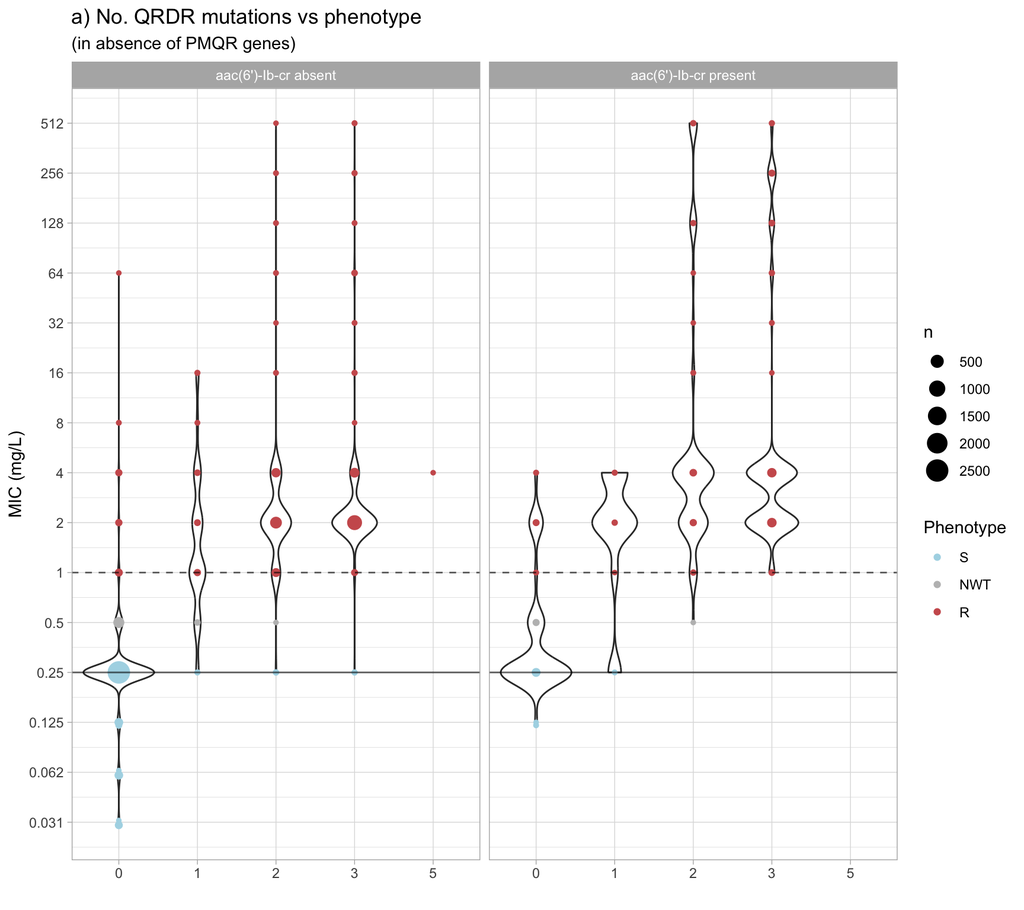

```r
#MIC distribution for # QRDR, in absence of genes
QRDR_MIC_noGenes <- cipro_antibiogram %>%
    filter(acquired_genes==0) %>%
    filter(grepl('MIC.*$', Laboratory.Typing.Method)) %>%
    mutate(aac6_label=if_else(aac6==0, "aac(6ʹ)-Ib-cr absent", "aac(6ʹ)-Ib-cr present")) %>%
    mutate(QRDR_mutations=if_else(QRDR_mutations==4, 3, QRDR_mutations)) %>% # single isolate with 4 QRDR
    ggplot(aes(x=factor(QRDR_mutations), y=as.numeric(Measurement))) +
    geom_violin() +
    geom_count(aes(colour = SRnwt)) +
    geom_hline(aes(yintercept = 1), linetype = 2, alpha = 0.6, color = "black")  +
    geom_hline(aes(yintercept = 0.25), linetype = 1, alpha = 0.6, color = "black")  +
    facet_wrap(vars(aac6_label)) +
    scale_y_continuous(trans = log2_trans(), breaks = 2^(-5:9), labels = function(x) round(as.numeric(x), digits = 3)) +
    scale_color_manual(values = res_colours) +
    theme_light() +
    labs(y="MIC (mg/L)", x="", col="Phenotype",
         title="a) No. QRDR mutations vs phenotype",
         subtitle="(in absence of PMQR genes)")

QRDR_MIC_noGenes
```

```r
QRDR_pheno_noGenes <- cipro_antibiogram %>%
    filter(acquired_genes==0) %>%
    filter(grepl('MIC.*$', Laboratory.Typing.Method)) %>%
    mutate(aac6_label=if_else(aac6==0, "aac(6ʹ)-Ib-cr absent", "aac(6ʹ)-Ib-cr present")) %>%
    mutate(QRDR_mutations=if_else(QRDR_mutations==4, 3, QRDR_mutations)) %>% # single isolate with 4 QRDR
    ggplot(aes(x=factor(QRDR_mutations), fill=SRnwt)) +
    geom_bar(stat='count', position='fill') +
    facet_wrap(vars(aac6_label)) +
    scale_fill_manual(values = res_colours) +
    scale_y_continuous(labels=scales::percent_format()) +
    geom_text(aes(label=..count..), stat="count", position=position_fill(vjust = .5), size=2) +
    theme_light() +
    labs(y="% Phenotype", x="Number of QRDR mutations") +
    theme(legend.position="none", strip.background = element_blank(), strip.text = element_blank())
```

# Fig S6 - number of QRDR vs DD, facet aac6 yes/no (no other genes)

```r
# DD distribution for # QRDR, in absence of genes
QRDR_DD_noGenes <- cipro_antibiogram %>%
    filter(acquired_genes==0) %>%
    filter(Laboratory.Typing.Method=="Disk diffusion") %>%
    mutate(aac6_label=if_else(aac6==0, "aac(6ʹ)-Ib-cr absent", "aac(6ʹ)-Ib-cr present")) %>%
    mutate(QRDR_mutations=if_else(QRDR_mutations==4, 3, QRDR_mutations)) %>% # single isolate with 4 QRDR
    ggplot(aes(x=factor(QRDR_mutations), y=as.numeric(Measurement))) +
    geom_violin() +
    geom_count(aes(colour = SRnwt)) +
    geom_hline(aes(yintercept = 21.0), linetype = 1, alpha = 0.6, color = "black") +
    geom_hline(aes(yintercept = 25.0), linetype = 2, alpha = 0.6, color = "black") +
    facet_wrap(vars(aac6_label)) +
    scale_colour_manual(values = res_colours) +
    theme_light() +
    labs(y="Disk diffusion\n zone diameter (mm)", x="", col="Phenotype",
         title="No. QRDR mutations vs phenotype",
         subtitle="(in absence of PMQR genes)")

QRDR_DDpheno_noGenes <- cipro_antibiogram %>%
    filter(acquired_genes==0) %>%
    filter(Laboratory.Typing.Method=="Disk diffusion") %>%
    mutate(aac6_label=if_else(aac6==0, "aac(6ʹ)-Ib-cr absent", "aac(6ʹ)-Ib-cr present")) %>%
    mutate(QRDR_mutations=if_else(QRDR_mutations==4, 3, QRDR_mutations)) %>% # single isolate with 4 QRDR
    ggplot(aes(x=factor(QRDR_mutations), fill=SRnwt)) +
    geom_bar(stat='count', position='fill') +
    facet_wrap(vars(aac6_label)) +
    scale_fill_manual(values = res_colours) +
    scale_y_continuous(labels=scales::percent_format()) +
    geom_text(aes(label=..count..), stat="count", position=position_fill(vjust = .5), size=2) +
    theme_light() +
    labs(y="% Phenotype", x="Number of QRDR mutations") +
    theme(legend.position="none", strip.background = element_blank(), strip.text = element_blank())
```

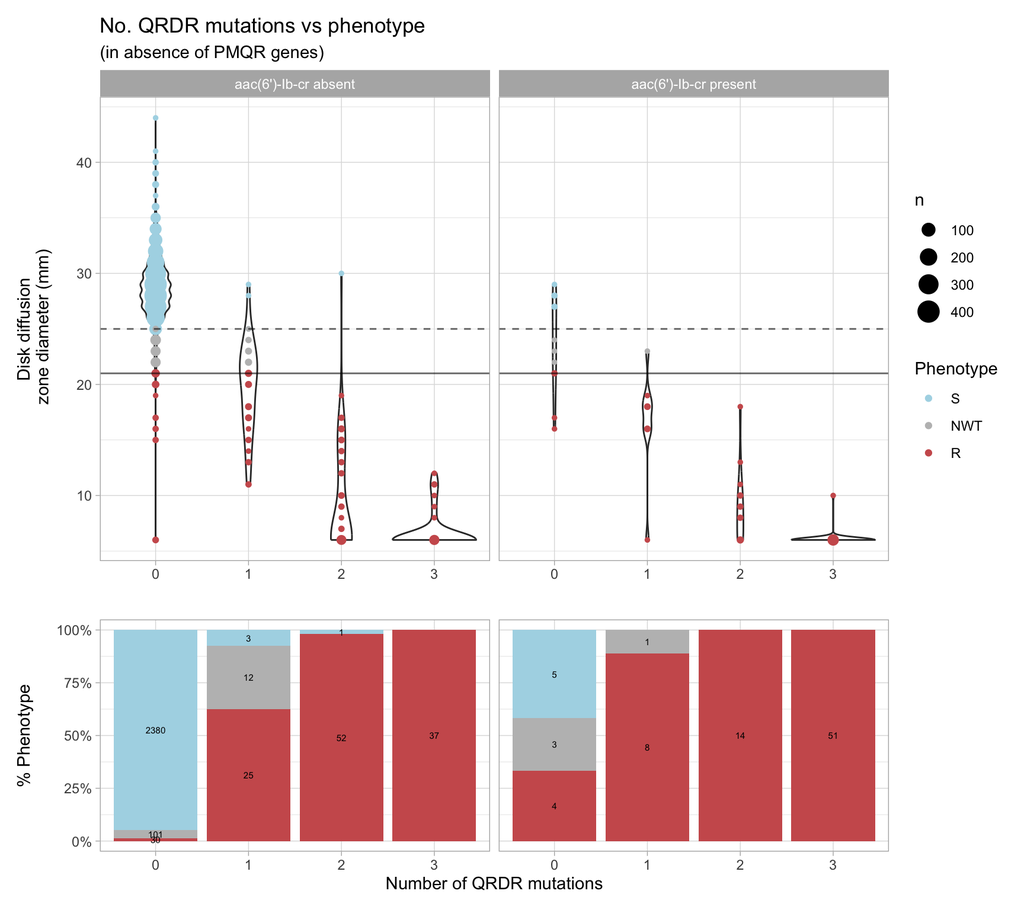

```r
QRDR_DD_noGenes / QRDR_DDpheno_noGenes + plot_layout(heights=c(2,1))
```

```r
ggsave("figs/FigS6_numQRDR_DD_pheno.pdf", width=6, height=4)
ggsave("figs/FigS6_numQRDR_DD_pheno.png", width=6, height=4)
```

# Fig S4 panel a - upset plot of QRDR positions, absence of aac6/acquired genes, with MIC data

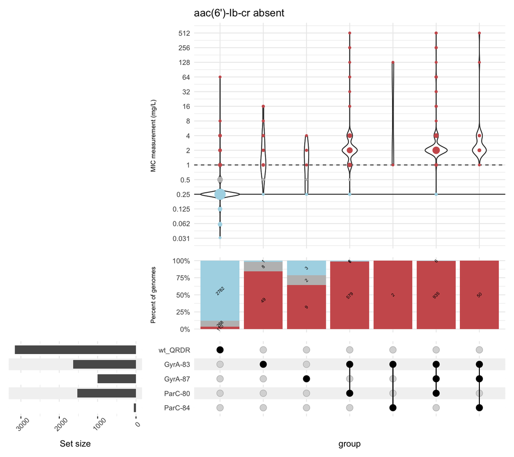

```r
upset_QRDR_noAac6_MIC <- cipro_antibiogram %>%
  filter(aac6==0 & acquired_genes==0) %>%
  filter(grepl('MIC.*$', Laboratory.Typing.Method)) %>%
  upset(
      intersect=c("ParC-84","ParC-80","GyrA-87","GyrA-83","wt_QRDR"), # counts are converted to binary
        sort_sets=FALSE,
      intersections=list(
        'wt_QRDR',
        "GyrA-83",
        "GyrA-87",
        c("GyrA-83","ParC-80"),
        c("GyrA-83","ParC-84"),
        c("GyrA-83","GyrA-87","ParC-80"),
        c("GyrA-83","GyrA-87","ParC-84")),
        sort_intersections=FALSE,
      set_sizes=(upset_set_size() +
                    theme(axis.text.x=element_text(angle=45),axis.ticks.x=element_line())),
      base_annotations=list( # add stacked barplot showing WT/nonWT
        'Percent of genomes'=list(
        aes=aes(x=intersection, fill=SRnwt),
          geom=list(
            geom_bar(stat='count', position='fill'),
            theme(legend.position = "none", axis.title=element_text(size=8)),
                 scale_fill_manual(values = res_colours),
            scale_y_continuous(labels=scales::percent_format()),
            geom_text(aes(label=..count..), stat="count", position=position_fill(vjust = .5), angle = 45, size=2))
        )
      ),
      annotations= list( # add violin plot with MIC data
        'MIC measurement (mg/L)'=(
            ggplot(mapping=aes(y=as.numeric(Measurement))) +
              geom_hline(aes(yintercept = 1), linetype = 2, alpha = 0.6, color = "black")  +
              geom_hline(aes(yintercept = 0.25), linetype = 1, alpha = 0.6, color = "black")  +
              geom_violin()+
              geom_count(aes(colour = SRnwt))+
               scale_colour_manual(values = res_colours) +
              scale_y_continuous(trans = log2_trans(), breaks = 2^(-5:9), labels = function(x) round(as.numeric(x), digits = 3), limits=c(2^-5,2^9)) +
              theme(legend.position = "none", axis.title=element_text(size=8))  +
              ggtitle("aac(6ʹ)-Ib-cr absent")
        )
      )
    ) + patchwork::plot_layout(heights=c(3,1,1)) # relative heights of plotting areas

upset_QRDR_noAac6_MIC
```

# Fig S4 panel b - upset plot of QRDR positions, presence of aac6 but no other acquired genes, with MIC data

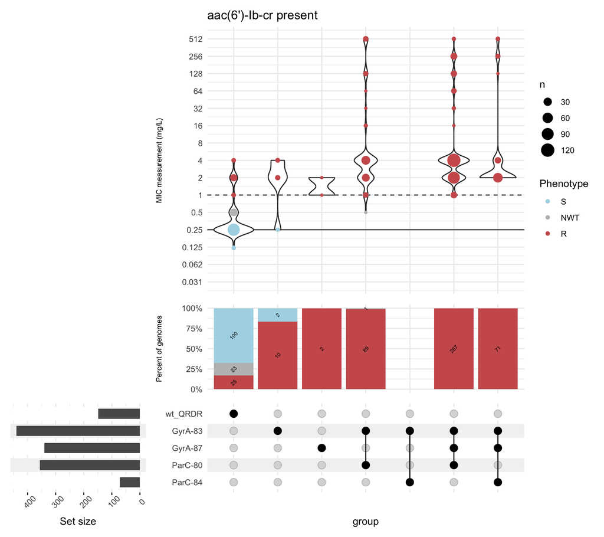

```r
upset_QRDR_aac6_MIC <- cipro_antibiogram %>%
  filter(aac6==1 & acquired_genes==0) %>%
  filter(grepl('MIC.*$', Laboratory.Typing.Method)) %>%
  upset(
      intersect=c("ParC-84","ParC-80","GyrA-87","GyrA-83","wt_QRDR"), # counts are converted to binary
        sort_sets=FALSE,
      intersections=list(
        'wt_QRDR',
        "GyrA-83",
        "GyrA-87",
        c("GyrA-83","ParC-80"),
        c("GyrA-83","ParC-84"),
        c("GyrA-83","GyrA-87","ParC-80"),
        c("GyrA-83","GyrA-87","ParC-84")),
        sort_intersections=FALSE,
      set_sizes=(upset_set_size() +
                    theme(axis.text.x=element_text(angle=45),axis.ticks.x=element_line())),
      base_annotations=list( # add stacked barplot showing WT/nonWT
        'Percent of genomes'=list(
        aes=aes(x=intersection, fill=SRnwt),
          geom=list(
            geom_bar(stat='count', position='fill'),
            theme(legend.position = "none", axis.title=element_text(size=8)),
              scale_fill_manual(values = res_colours),
            scale_y_continuous(labels=scales::percent_format()),
            geom_text(aes(label=..count..), stat="count", position=position_fill(vjust = .5), angle = 45, size=2))
        )
      ),
      annotations= list( # add violin plot with MIC data
        'MIC measurement (mg/L)'=(
            ggplot(mapping=aes(y=as.numeric(Measurement))) +
              geom_hline(aes(yintercept = 1), linetype = 2, alpha = 0.6, color = "black")  +
              geom_hline(aes(yintercept = 0.25), linetype = 1, alpha = 0.6, color = "black")  +
              geom_violin()+
              geom_count(aes(colour = SRnwt))+
               scale_colour_manual(values = res_colours) +
              scale_y_continuous(trans = log2_trans(), breaks = 2^(-5:9), labels = function(x) round(as.numeric(x), digits = 3), limits=c(2^-5,2^9)) +
              labs(colour = "Phenotype") +
              theme(axis.title=element_text(size=8)) +
              ggtitle("aac(6ʹ)-Ib-cr present")
        )
      )
    ) + patchwork::plot_layout(heights=c(3,1,1)) # relative heights of plotting areas
upset_QRDR_aac6_MIC
```

# Fig S5 panel a - QRDR positions, absence of aac6/acquired genes, with DD data

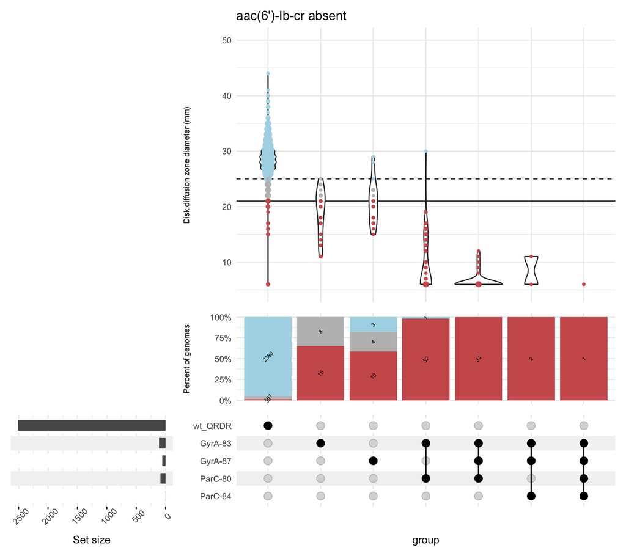

```r
upset_QRDR_noAac6_DD <- cipro_antibiogram %>%
  filter(aac6==0 & acquired_genes==0) %>%
  filter(Laboratory.Typing.Method == "Disk diffusion") %>%
  upset(
      intersect=c("ParC-84","ParC-80","GyrA-87","GyrA-83","wt_QRDR"), # counts are converted to binary
        sort_sets=FALSE,
      intersections=list(
        'wt_QRDR',
        "GyrA-83",
        "GyrA-87",
        c("GyrA-83","ParC-80"),
        c("GyrA-83","GyrA-87","ParC-80"),
        c("GyrA-83","GyrA-87","ParC-84"),
        c("GyrA-83","GyrA-87","ParC-80","ParC-84")),
        sort_intersections=FALSE,
      set_sizes=(upset_set_size() +
                    theme(axis.text.x=element_text(angle=45), axis.ticks.x=element_line())),
      base_annotations=list( # add stacked barplot showing S/nonS
        'Percent of genomes'=list(
        aes=aes(x=intersection, fill=SRnwt),
          geom=list(
            geom_bar(stat='count', position='fill'),
             scale_fill_manual(values = res_colours),
            scale_y_continuous(labels=scales::percent_format()),
            theme(legend.position = "none", axis.title=element_text(size=8)),
            geom_text(aes(label=..count..), stat="count", position=position_fill(vjust = .5), angle = 45, size=2))
        )
      ),
      annotations= list( # add violin plot with disk diffusion data
        'Disk diffusion zone diameter (mm)'=(
            ggplot(mapping=aes(y=as.numeric(Measurement))) +
              geom_hline(aes(yintercept = 21.0), linetype = 1, alpha = 0.6, color = "black") +
              geom_hline(aes(yintercept = 25.0), linetype = 2, alpha = 0.6, color = "black") +
              geom_violin()+
              geom_count(aes(colour = SRnwt))+
               scale_colour_manual(values = res_colours) +
              guides(size = "none") +
              labs(linetype = "CLSI/EUCAST", colour = "Phenotype") +
              ggtitle("Disk diffusion data") +
              theme(axis.title=element_text(size=8), legend.position="none") +
              ggtitle("aac(6ʹ)-Ib-cr absent") + ylim(5,50)
        )
      )
    ) + patchwork::plot_layout(heights=c(3,1,1)) # relative heights of plotting areas

upset_QRDR_noAac6_DD
```

# Fig S5 panel b - QRDR positions, presence of aac6 but no other acquired genes, with DD data

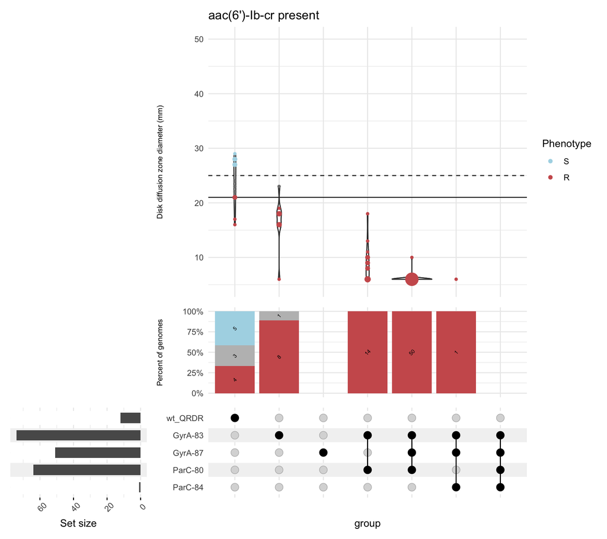

```r
upset_QRDR_aac6_DD <- cipro_antibiogram %>%
  filter(aac6==1 & acquired_genes==0) %>%
  filter(Laboratory.Typing.Method == "Disk diffusion") %>%
  upset(
      intersect=c("ParC-84","ParC-80","GyrA-87","GyrA-83","wt_QRDR"), # counts are converted to binary
        sort_sets=FALSE,
      intersections=list(
        'wt_QRDR',
        "GyrA-83",
        "GyrA-87",
        c("GyrA-83","ParC-80"),
        c("GyrA-83","GyrA-87","ParC-80"),
        c("GyrA-83","GyrA-87","ParC-84"),
        c("GyrA-83","GyrA-87","ParC-80","ParC-84")),
        sort_intersections=FALSE,      set_sizes=(upset_set_size() +
                    theme(axis.text.x=element_text(angle=45), axis.ticks.x=element_line())),
      base_annotations=list( # add stacked barplot showing S/nonS
        'Percent of genomes'=list(
        aes=aes(x=intersection, fill=SRnwt),
          geom=list(
            geom_bar(stat='count', position='fill'),
               scale_fill_manual(values = res_colours),
            scale_y_continuous(labels=scales::percent_format()),
            theme(legend.position = "none", axis.title=element_text(size=8)),
            geom_text(aes(label=..count..), stat="count", position=position_fill(vjust = .5), angle = 45, size=2))
        )
      ),
      annotations= list( # add violin plot with disk diffusion data
        'Disk diffusion zone diameter (mm)'=(
            ggplot(mapping=aes(y=as.numeric(Measurement))) +
              geom_hline(aes(yintercept = 21.0), linetype = 1, alpha = 0.6, color = "black") +
              geom_hline(aes(yintercept = 25.0), linetype = 2, alpha = 0.6, color = "black") +
              geom_violin()+
              geom_count(aes(colour = SRnwt))+
               scale_color_manual(values = c("I"="grey", "R"="IndianRed", "S"="LightBlue")) +
              guides(size = "none") +
              labs(linetype = "CLSI/EUCAST", colour = "Phenotype") +
              ggtitle("aac(6ʹ)-Ib-cr present") +
              theme(axis.title=element_text(size=8)) + ylim(5,50)
        )
      )
    ) + patchwork::plot_layout(heights=c(3,1,1)) # relative heights of plotting areas

upset_QRDR_aac6_DD
```

## Supp Figs 4 and 5: QRDR sites vs pheno (MIC & DD, with/without aac6)

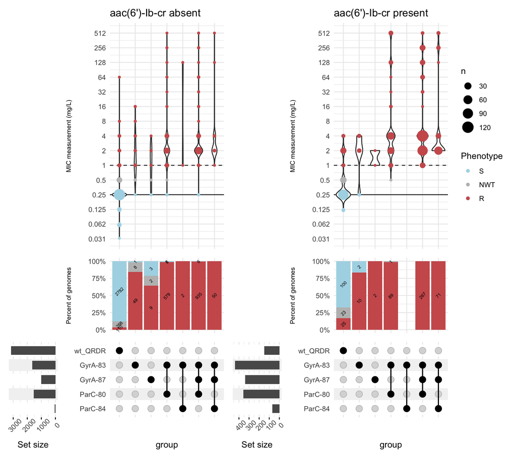

```r
upset_QRDR_noAac6_MIC | upset_QRDR_aac6_MIC
```

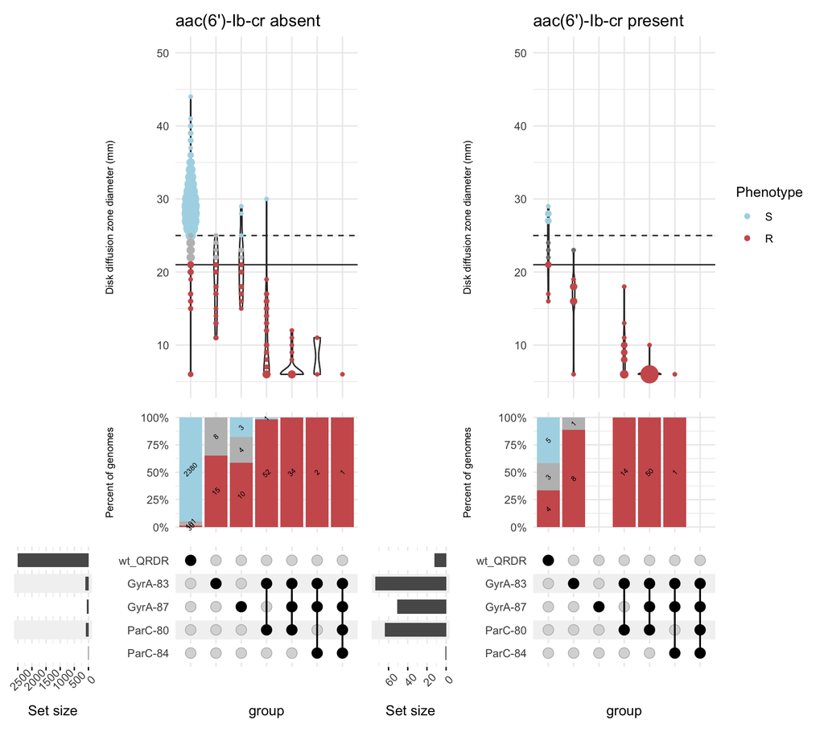

```r
ggsave("figs/FigS4_QRDR_MIC.pdf", width=9, height=6)
ggsave("figs/FigS4_QRDR_MIC.png", width=9, height=6)


upset_QRDR_noAac6_DD | upset_QRDR_aac6_DD
```

```r
ggsave("figs/FigS5_QRDR_DD.pdf", width=9, height=6)
ggsave("figs/FigS5_QRDR_DD.png", width=9, height=6)
```

## set up binary variables for common PMQR genes

```r
# genes in at least 10 genomes
qnr_genes <- cipro_res_mech %>%
  mutate(marker=gsub("[\\^\\*\\?]", "", marker)) %>%
  mutate(marker=gsub(".v1", "", marker)) %>%
  mutate(marker=gsub(".v2", "", marker)) %>%
  group_by(marker) %>%
  count() %>% filter(startsWith(marker, "q")) %>%
  filter(n>10) %>% pull(marker)

qnr_presence <- cipro_res_mech %>%
  mutate(marker=gsub("[\\^\\*\\?]", "", marker)) %>%
  mutate(marker=gsub(".v1", "", marker)) %>%
  mutate(marker=gsub(".v2", "", marker)) %>%
  filter(marker %in% qnr_genes) %>%
  group_by(strain, marker) %>% count() %>% pivot_wider(names_from=marker, values_from=n)

cipro_antibiogram <- left_join(cipro_antibiogram, qnr_presence)
```

# Fig S7 panel a - upset plot of qnr genes, absence of aac6 and QRDR, with MIC data

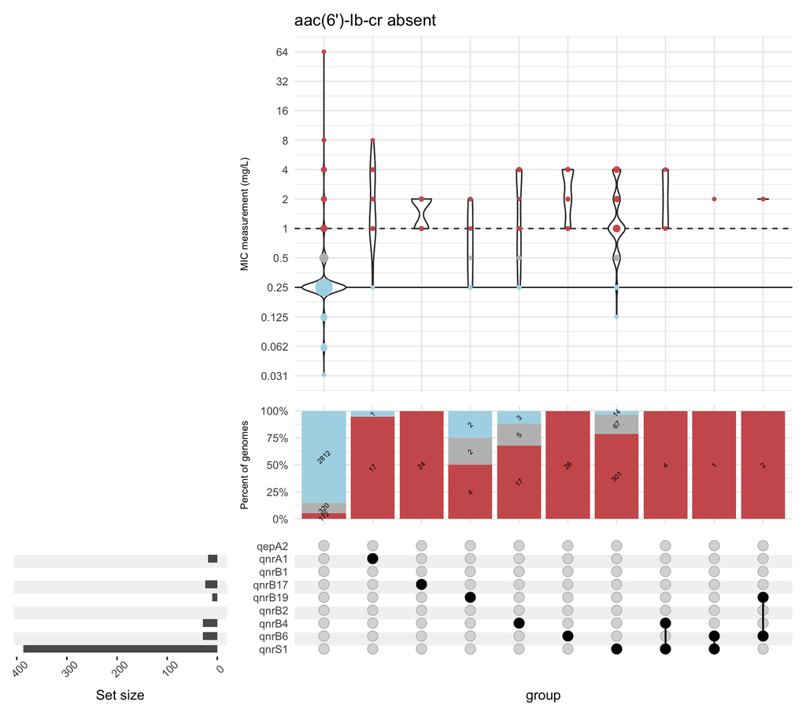

```r
upset_qnr_noAac6_MIC <- cipro_antibiogram %>%
  filter(aac6==0 & QRDR_mutations==0) %>%
  filter(grepl('MIC.*$', Laboratory.Typing.Method)) %>%
  upset(
      intersect=rev(qnr_genes),
      sort_sets=FALSE,
        intersections=list(
        'Outside of known sets',
        "qnrA1",
        "qnrB17",
        "qnrB19",
        "qnrB4",
        "qnrB6",
        "qnrS1",
        c("qnrB4","qnrS1"),
        c("qnrB6","qnrS1"),
        c("qnrB6","qnrB19")),
        sort_intersections=FALSE,
      set_sizes=(upset_set_size() +
                    theme(axis.text.x=element_text(angle=45),axis.ticks.x=element_line())),
      base_annotations=list( # add stacked barplot showing S/nonS
        'Percent of genomes'=list(
        aes=aes(x=intersection, fill=SRnwt),
          geom=list(
            geom_bar(stat='count', position='fill'),
            theme(legend.position = "none", axis.title=element_text(size=8)),
             scale_fill_manual(values = res_colours),
            scale_y_continuous(labels=scales::percent_format()),
            geom_text(aes(label=..count..), stat="count", position=position_fill(vjust = .5), angle = 45, size=2))
        )
      ),
      annotations= list( # add violin plot with MIC data
        'MIC measurement (mg/L)'=(
            ggplot(mapping=aes(y=as.numeric(Measurement))) +
              geom_hline(aes(yintercept = 1), linetype = 2, alpha = 0.6, color = "black")  +
              geom_hline(aes(yintercept = 0.25), linetype = 1, alpha = 0.6, color = "black")  +
              geom_violin()+
              geom_count(aes(colour = SRnwt))+
              scale_color_manual(values = res_colours)+
              scale_y_continuous(trans = log2_trans(), breaks = 2^(-5:6), labels = function(x) round(as.numeric(x), digits = 3), limits=c(2^-5,2^6)) +
              theme(legend.position = "none", axis.title=element_text(size=8))  +
              ggtitle("aac(6ʹ)-Ib-cr absent")
        )
      )
    ) + patchwork::plot_layout(heights=c(3,1,1)) # relative heights of plotting areas
upset_qnr_noAac6_MIC
```

# Fig S7 panel- upset plot of qnr genes, presence of aac6 but no QRDR, with MIC data

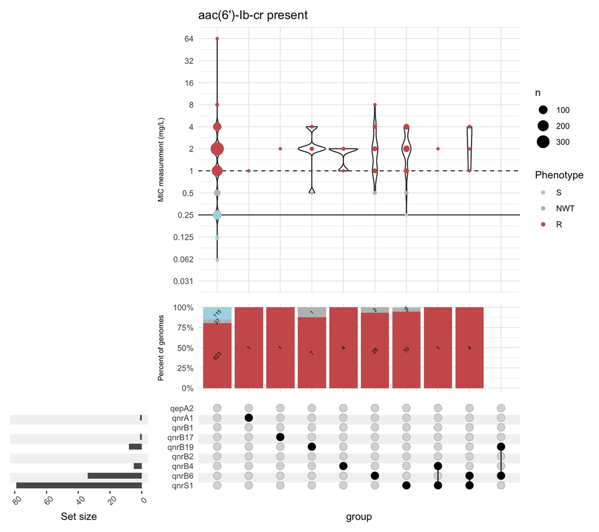

```r
upset_qnr_aac6_MIC <- cipro_antibiogram %>%
  filter(aac6==1 & QRDR_mutations==0) %>%
  filter(grepl('MIC.*$', Laboratory.Typing.Method)) %>%
  upset(
      intersect=rev(qnr_genes),
      sort_sets=FALSE,
        intersections=list(
        'Outside of known sets',
        "qnrA1",
        "qnrB17",
        "qnrB19",
        "qnrB4",
        "qnrB6",
        "qnrS1",
        c("qnrB4","qnrS1"),
        c("qnrB6","qnrS1"),
        c("qnrB6","qnrB19")),
        sort_intersections=FALSE,
      set_sizes=(upset_set_size() +
                    theme(axis.text.x=element_text(angle=45),axis.ticks.x=element_line())),
      base_annotations=list( # add stacked barplot showing S/nonS
        'Percent of genomes'=list(
        aes=aes(x=intersection, fill=SRnwt),
          geom=list(
            geom_bar(stat='count', position='fill'),
            theme(legend.position = "none", axis.title=element_text(size=8)),
             scale_fill_manual(values = res_colours),
            scale_y_continuous(labels=scales::percent_format()),
            geom_text(aes(label=..count..), stat="count", position=position_fill(vjust = .5), angle = 45, size=2))
        )
      ),
      annotations= list( # add violin plot with MIC data
        'MIC measurement (mg/L)'=(
            ggplot(mapping=aes(y=as.numeric(Measurement))) +
              geom_hline(aes(yintercept = 1), linetype = 2, alpha = 0.6, color = "black")  +
              geom_hline(aes(yintercept = 0.25), linetype = 1, alpha = 0.6, color = "black")  +
              geom_violin()+
              geom_count(aes(colour = SRnwt))+
                scale_color_manual(values = res_colours)+
              scale_y_continuous(trans = log2_trans(), breaks = 2^(-5:6), labels = function(x) round(as.numeric(x), digits = 3), limits=c(2^-5,2^6)) +
              labs(colour = "Phenotype") +
              theme(axis.title=element_text(size=8)) +
              ggtitle("aac(6ʹ)-Ib-cr present")
        )
      )
    ) + patchwork::plot_layout(heights=c(3,1,1)) # relative heights of plotting areas
upset_qnr_aac6_MIC
```

# Fig S8 panel - qnr genes, absence of aac6 and QRDR mutations, with DD data

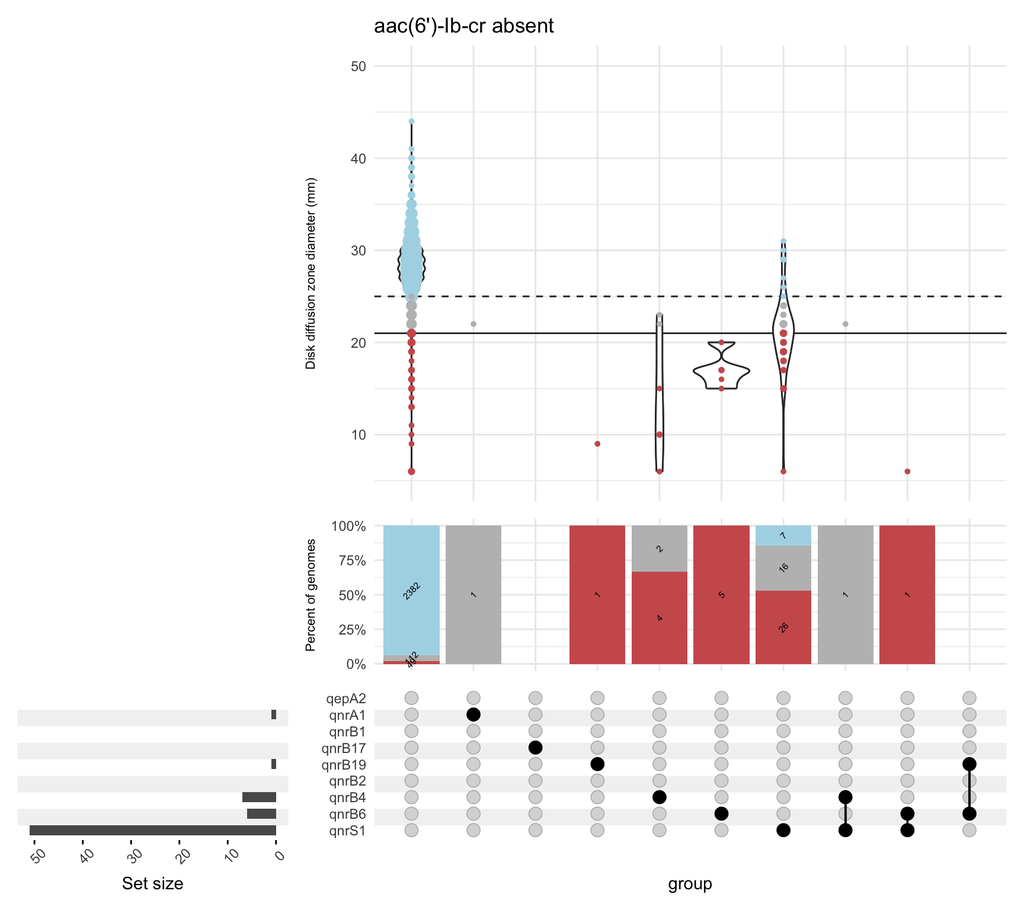

```r
upset_qnr_noAac6_DD <- cipro_antibiogram %>%
  filter(aac6==0 & QRDR_mutations==0) %>%
  filter(Laboratory.Typing.Method == "Disk diffusion") %>%
  upset(
      intersect=rev(qnr_genes),
      sort_sets=FALSE,
        intersections=list(
        'Outside of known sets',
        "qnrA1",
        "qnrB17",
        "qnrB19",
        "qnrB4",
        "qnrB6",
        "qnrS1",
        c("qnrB4","qnrS1"),
        c("qnrB6","qnrS1"),
        c("qnrB6","qnrB19")),
        sort_intersections=FALSE,
      set_sizes=(upset_set_size() +
                    theme(axis.text.x=element_text(angle=45), axis.ticks.x=element_line())),
      base_annotations=list( # add stacked barplot showing S/nonS
        'Percent of genomes'=list(
        aes=aes(x=intersection, fill=SRnwt),
          geom=list(
            geom_bar(stat='count', position='fill'),
               scale_fill_manual(values = res_colours),
            scale_y_continuous(labels=scales::percent_format()),
            theme(legend.position = "none", axis.title=element_text(size=8)),
            geom_text(aes(label=..count..), stat="count", position=position_fill(vjust = .5), angle = 45, size=2))
        )
      ),
      annotations= list( # add violin plot with disk diffusion data
        'Disk diffusion zone diameter (mm)'=(
            ggplot(mapping=aes(y=as.numeric(Measurement))) +
              geom_hline(aes(yintercept = 21.0), linetype = 1, alpha = 0.6, color = "black") +
              geom_hline(aes(yintercept = 25.0), linetype = 2, alpha = 0.6, color = "black") +
              geom_violin()+
              geom_count(aes(colour = SRnwt))+
                scale_color_manual(values = res_colours)+
              guides(size = "none") +
              labs(linetype = "CLSI/EUCAST", colour = "Phenotype") +
              ggtitle("Disk diffusion data") +
              theme(axis.title=element_text(size=8), legend.position="none") +
              ggtitle("aac(6ʹ)-Ib-cr absent") + ylim(5,50)
        )
      )
    ) + patchwork::plot_layout(heights=c(3,1,1)) # relative heights of plotting areas

upset_qnr_noAac6_DD
```

# Fig S8 panel - qnr genes, presence of aac6 but no QRDR mutations, with DD data

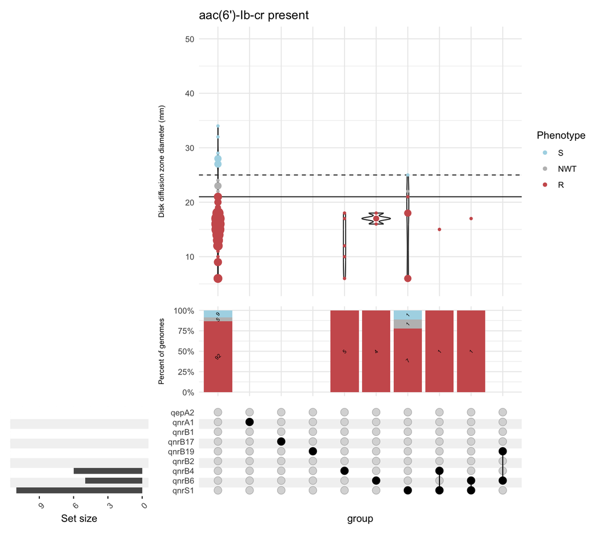

```r
upset_qnr_aac6_DD <- cipro_antibiogram %>%
  filter(aac6==1 & QRDR_mutations==0) %>%
  filter(Laboratory.Typing.Method == "Disk diffusion") %>%
  upset(
      intersect=rev(qnr_genes),
      sort_sets=FALSE,
        intersections=list(
        'Outside of known sets',
        "qnrA1",
        "qnrB17",
        "qnrB19",
        "qnrB4",
        "qnrB6",
        "qnrS1",
        c("qnrB4","qnrS1"),
        c("qnrB6","qnrS1"),
        c("qnrB6","qnrB19")),
        sort_intersections=FALSE,
      set_sizes=(upset_set_size() +
                    theme(axis.text.x=element_text(angle=45), axis.ticks.x=element_line())),
      base_annotations=list( # add stacked barplot showing S/nonS
        'Percent of genomes'=list(
        aes=aes(x=intersection, fill=SRnwt),
          geom=list(
            geom_bar(stat='count', position='fill'),
               scale_fill_manual(values = res_colours),
            scale_y_continuous(labels=scales::percent_format()),
            theme(legend.position = "none", axis.title=element_text(size=8)),
            geom_text(aes(label=..count..), stat="count", position=position_fill(vjust = .5), angle = 45, size=2))
        )
      ),
      annotations= list( # add violin plot with disk diffusion data
        'Disk diffusion zone diameter (mm)'=(
            ggplot(mapping=aes(y=as.numeric(Measurement))) +
              geom_hline(aes(yintercept = 21.0), linetype = 1, alpha = 0.6, color = "black") +
              geom_hline(aes(yintercept = 25.0), linetype = 2, alpha = 0.6, color = "black") +
              geom_violin()+
              geom_count(aes(colour = SRnwt))+
                scale_color_manual(values = res_colours)+
              guides(size = "none") +
              labs(linetype = "CLSI/EUCAST", colour = "Phenotype") +
              ggtitle("aac(6ʹ)-Ib-cr present") +
              theme(axis.title=element_text(size=8)) + ylim(5,50)
        )
      )
    ) + patchwork::plot_layout(heights=c(3,1,1)) # relative heights of plotting areas

upset_qnr_aac6_DD
```

# Supp Figs S7 and S8: qnr genes vs pheno (MIC & DD, with/without aac6)

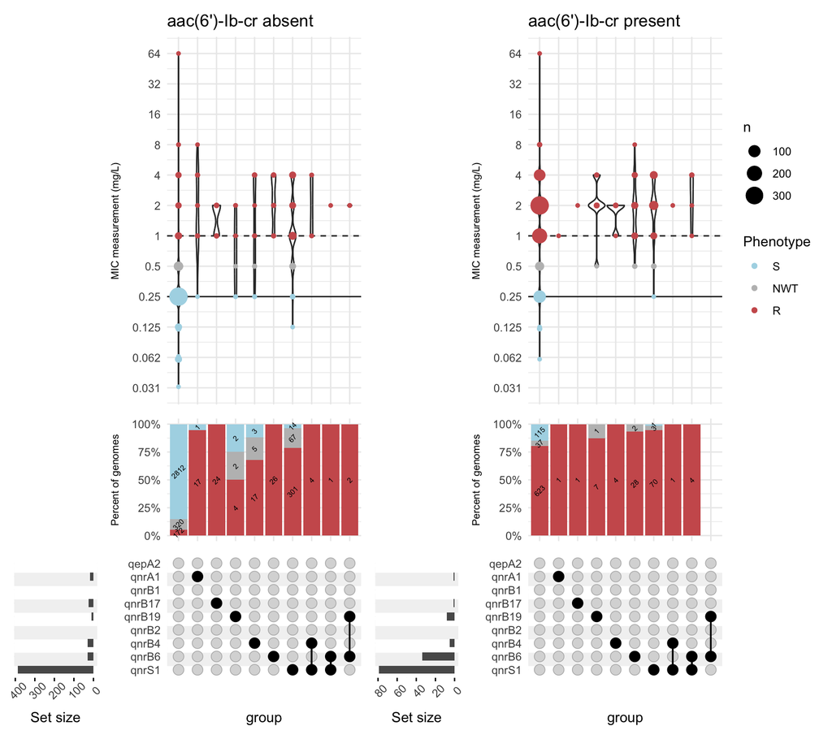

```r
upset_qnr_noAac6_MIC | upset_qnr_aac6_MIC
```

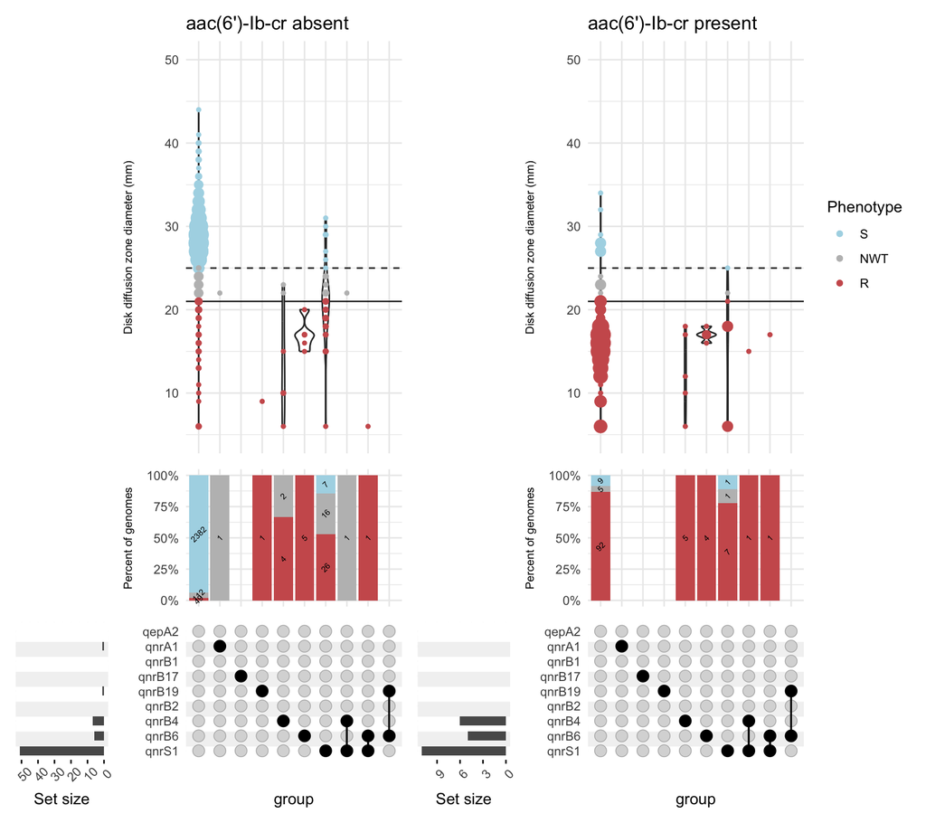

```r
ggsave("figs/FigS7_qnr_MIC.pdf", width=12, height=6)
ggsave("figs/FigS7_qnr_MIC.png", width=12, height=6)


upset_qnr_noAac6_DD | upset_qnr_aac6_DD
```

```r
ggsave("figs/FigS8_qnr_DD.pdf", width=12, height=6)
ggsave("figs/FigS8_qnr_DD.png", width=12, height=6)
```

# numbers for text - paragraph 5

```r
# effect of qnr/qep genes, in absence of QRDR and aac6

# MIC data in absence of QRDR and aac6
qnr_MIC_nullBG_dat <- cipro_antibiogram %>%
  filter(Laboratory.Typing.Method !="Disk diffusion") %>%
  filter(aac6==0 & QRDR_mutations==0) %>%
  select(Measurement, Resistance.phenotype, resistant, nonWT_binary, acquired_genes) %>%
  mutate(acquired_bin=if_else(acquired_genes==0, 0, 1))

# MIC vs presence/absence of qnr, in absence of QRDR and aac6
summary(as.numeric(qnr_MIC_nullBG_dat$Measurement)[qnr_MIC_nullBG_dat$acquired_bin==1])
```

```
##    Min. 1st Qu.  Median    Mean 3rd Qu.    Max.
##   0.125   0.500   1.000   1.575   2.000   8.000
```

```r
summary(as.numeric(qnr_MIC_nullBG_dat$Measurement)[qnr_MIC_nullBG_dat$acquired_bin==0])
```

```
##    Min. 1st Qu.  Median    Mean 3rd Qu.    Max.
##  0.0300  0.2500  0.2500  0.3421  0.2500 64.0000
```

```r
wilcox.test(log2(as.numeric(Measurement)) ~ acquired_bin, data=qnr_MIC_nullBG_dat)
```

```
##
##  Wilcoxon rank sum test with continuity correction
##
## data:  log2(as.numeric(Measurement)) by acquired_bin
## W = 140287, p-value < 2.2e-16
## alternative hypothesis: true location shift is not equal to 0
```

```r
summary(lm(log2(as.numeric(Measurement)) ~ acquired_bin, data=qnr_MIC_nullBG_dat))
```

```
##
## Call:
## lm(formula = log2(as.numeric(Measurement)) ~ acquired_bin, data = qnr_MIC_nullBG_dat)
##
## Residuals:
##     Min      1Q  Median      3Q     Max
## -3.1845 -0.0414 -0.0414 -0.0414  7.9586
##
## Coefficients:
##              Estimate Std. Error t value Pr(>|t|)
## (Intercept)  -1.95856    0.01615 -121.24   <2e-16 ***
## acquired_bin  2.14311    0.03952   54.23   <2e-16 ***
## ---
## Signif. codes:  0 '***' 0.001 '**' 0.01 '*' 0.05 '.' 0.1 ' ' 1
##
## Residual standard error: 0.9081 on 3792 degrees of freedom
## Multiple R-squared:  0.4368, Adjusted R-squared:  0.4367
## F-statistic:  2941 on 1 and 3792 DF,  p-value: < 2.2e-16
```

```r
# DD data in absence of QRDR and aac6
qnr_DD_noGenes_dat <- cipro_antibiogram %>%
    filter(aac6==0 & QRDR_mutations==0) %>%
    filter(Laboratory.Typing.Method=="Disk diffusion") %>%
  select(Measurement, Resistance.phenotype, resistant, nonWT_binary, acquired_genes) %>%
  mutate(acquired_bin=if_else(acquired_genes==0, 0, 1))

# DD vs presence/absence of qnr, in absence of QRDR and aac6

summary(as.numeric(qnr_DD_noGenes_dat$Measurement)[qnr_DD_noGenes_dat$acquired_bin==1])
```

```
##    Min. 1st Qu.  Median    Mean 3rd Qu.    Max.
##    6.00   17.00   21.00   19.51   22.00   31.00
```

```r
summary(as.numeric(qnr_DD_noGenes_dat$Measurement)[qnr_DD_noGenes_dat$acquired_bin==0])
```

```
##    Min. 1st Qu.  Median    Mean 3rd Qu.    Max.
##    6.00   27.00   29.00   28.67   30.00   44.00
```

```r
wilcox.test(as.numeric(Measurement) ~ acquired_bin, data=qnr_DD_noGenes_dat)
```

```
##
##  Wilcoxon rank sum test with continuity correction
##
## data:  as.numeric(Measurement) by acquired_bin
## W = 230345, p-value < 2.2e-16
## alternative hypothesis: true location shift is not equal to 0
```

```r
summary(lm(as.numeric(Measurement) ~ acquired_bin, data=qnr_DD_noGenes_dat))
```

```
##
## Call:
## lm(formula = as.numeric(Measurement) ~ acquired_bin, data = qnr_DD_noGenes_dat)
##
## Residuals:
##      Min       1Q   Median       3Q      Max
## -22.6659  -1.6659   0.3341   1.3341  15.3341
##
## Coefficients:
##              Estimate Std. Error t value Pr(>|t|)
## (Intercept)  28.66587    0.05979  479.41   <2e-16 ***
## acquired_bin -9.15545    0.31160  -29.38   <2e-16 ***
## ---
## Signif. codes:  0 '***' 0.001 '**' 0.01 '*' 0.05 '.' 0.1 ' ' 1
##
## Residual standard error: 2.996 on 2605 degrees of freedom
## Multiple R-squared:  0.2489, Adjusted R-squared:  0.2486
## F-statistic: 863.3 on 1 and 2605 DF,  p-value: < 2.2e-16
```

```r
# all genomes with no acquired genes (MIC/DD)
qnr_noGenes_dat <- cipro_antibiogram %>%
    filter(aac6==0 & QRDR_mutations==0) %>%
  select(Measurement, Resistance.phenotype, resistant, nonWT_binary, acquired_genes) %>%
  mutate(acquired_bin=if_else(acquired_genes==0, 0, 1))

dim(qnr_noGenes_dat)
```

```
## [1] 6401    6
```

```r
# NWT vs presence/absence of qnr, in absence of QRDR and aac6
fisher.test(table(qnr_noGenes_dat$nonWT_binary, qnr_noGenes_dat$acquired_bin))
```

```
##
##  Fisher's Exact Test for Count Data
##
## data:  table(qnr_noGenes_dat$nonWT_binary, qnr_noGenes_dat$acquired_bin)
## p-value < 2.2e-16
## alternative hypothesis: true odds ratio is not equal to 1
## 95 percent confidence interval:
##   86.53681 155.63478
## sample estimates:
## odds ratio
##   115.5569
```

```r
# resistance vs presence/absence of qnr, in absence of QRDR and aac6
fisher.test(table(qnr_noGenes_dat$resistant, qnr_noGenes_dat$acquired_bin))
```

```
##
##  Fisher's Exact Test for Count Data
##
## data:  table(qnr_noGenes_dat$resistant, qnr_noGenes_dat$acquired_bin)
## p-value < 2.2e-16
## alternative hypothesis: true odds ratio is not equal to 1
## 95 percent confidence interval:
##   74.21361 119.59424
## sample estimates:
## odds ratio
##   93.70919
```

```r
# MIC vs qnr count
summary(lm(log2(as.numeric(Measurement)) ~ acquired_genes, data=qnr_MIC_nullBG_dat))
```

```
##
## Call:
## lm(formula = log2(as.numeric(Measurement)) ~ acquired_genes,
##     data = qnr_MIC_nullBG_dat)
##
## Residuals:
##     Min      1Q  Median      3Q     Max
## -3.1339 -0.0479 -0.0479 -0.0479  7.9521
##
## Coefficients:
##                Estimate Std. Error t value Pr(>|t|)
## (Intercept)    -1.95206    0.01614 -120.96   <2e-16 ***
## acquired_genes  2.04298    0.03781   54.03   <2e-16 ***
## ---
## Signif. codes:  0 '***' 0.001 '**' 0.01 '*' 0.05 '.' 0.1 ' ' 1
##
## Residual standard error: 0.9096 on 3792 degrees of freedom
## Multiple R-squared:  0.435,  Adjusted R-squared:  0.4348
## F-statistic:  2919 on 1 and 3792 DF,  p-value: < 2.2e-16
```

```r
summary(as.numeric(qnr_MIC_nullBG_dat$Measurement)[qnr_MIC_nullBG_dat$acquired_genes==1])
```

```
##    Min. 1st Qu.  Median    Mean 3rd Qu.    Max.
##   0.125   0.500   1.000   1.546   2.000   8.000
```

```r
summary(as.numeric(qnr_MIC_nullBG_dat$Measurement)[qnr_MIC_nullBG_dat$acquired_genes==2])
```

```
##    Min. 1st Qu.  Median    Mean 3rd Qu.    Max.
##     0.5     1.0     2.0     2.5     4.0     4.0
```

```r
summary(as.numeric(qnr_MIC_nullBG_dat$Measurement)[qnr_MIC_nullBG_dat$acquired_genes>2])
```

```
##    Min. 1st Qu.  Median    Mean 3rd Qu.    Max.
##
```

```r
# DD vs qnr count
summary(lm(as.numeric(Measurement) ~ acquired_genes, data=qnr_DD_noGenes_dat))
```

```
##
## Call:
## lm(formula = as.numeric(Measurement) ~ acquired_genes, data = qnr_DD_noGenes_dat)
##
## Residuals:
##      Min       1Q   Median       3Q      Max
## -22.6642  -1.6642   0.3358   1.3358  15.3358
##
## Coefficients:
##                Estimate Std. Error t value Pr(>|t|)
## (Intercept)    28.66417    0.05939  482.65   <2e-16 ***
## acquired_genes -8.65839    0.28782  -30.08   <2e-16 ***
## ---
## Signif. codes:  0 '***' 0.001 '**' 0.01 '*' 0.05 '.' 0.1 ' ' 1
##
## Residual standard error: 2.978 on 2605 degrees of freedom
## Multiple R-squared:  0.2578, Adjusted R-squared:  0.2575
## F-statistic:   905 on 1 and 2605 DF,  p-value: < 2.2e-16
```

```r
summary(as.numeric(qnr_DD_noGenes_dat$Measurement)[qnr_DD_noGenes_dat$acquired_genes==1])
```

```
##    Min. 1st Qu.  Median    Mean 3rd Qu.    Max.
##    6.00   18.00   21.00   19.91   22.50   31.00
```

```r
summary(as.numeric(qnr_DD_noGenes_dat$Measurement)[qnr_DD_noGenes_dat$acquired_genes==2])
```

```
##    Min. 1st Qu.  Median    Mean 3rd Qu.    Max.
##     6.0     6.0    10.0    12.2    17.0    22.0
```

```r
summary(as.numeric(qnr_DD_noGenes_dat$Measurement)[qnr_DD_noGenes_dat$acquired_genes>2])
```

```
##    Min. 1st Qu.  Median    Mean 3rd Qu.    Max.
##
```

# Figure 2 - number of qnr/qep vs MIC, facet aac6 yes/no (no QRDR)

```r
# MIC distribution for # QRDR, in absence of genes
qnr_MIC_noGenes <- cipro_antibiogram %>%
    filter(QRDR_mutations==0) %>%
    filter(grepl('MIC.*$', Laboratory.Typing.Method)) %>%
    mutate(aac6_label=if_else(aac6==0, "aac(6ʹ)-Ib-cr absent", "aac(6ʹ)-Ib-cr present")) %>%
    ggplot(aes(x=factor(acquired_genes), y=as.numeric(Measurement))) +
    geom_violin() +
    geom_count(aes(colour = SRnwt)) +
    geom_hline(aes(yintercept = 1), linetype = 2, alpha = 0.6, color = "black")  +
    geom_hline(aes(yintercept = 0.25), linetype = 1, alpha = 0.6, color = "black")  +
    facet_wrap(vars(aac6_label)) +
    scale_y_continuous(trans = log2_trans(), breaks = 2^(-5:9), labels = function(x) round(as.numeric(x), digits = 3)) +
    scale_color_manual(values = res_colours) +
    theme_light() +
    labs(y="MIC (mg/L)", x="", col="Phenotype",
         title="b) No. PMQR genes vs phenotype",
         subtitle="(in absence of QRDR mutations)")


qnr_pheno_noGenes <- cipro_antibiogram %>%
    filter(QRDR_mutations==0) %>%
    filter(grepl('MIC.*$', Laboratory.Typing.Method)) %>%
    mutate(aac6_label=if_else(aac6==0, "aac(6ʹ)-Ib-cr absent", "aac(6ʹ)-Ib-cr present")) %>%
    ggplot(aes(x=factor(acquired_genes), fill=SRnwt)) +
    geom_bar(stat='count', position='fill') +
    facet_wrap(vars(aac6_label)) +
       scale_fill_manual(values = res_colours) +
    scale_y_continuous(labels=scales::percent_format()) +
    geom_text(aes(label=..count..), stat="count", position=position_fill(vjust = .5), size=2) +
    theme_light() +
    labs(y="% Phenotype", x="Number of PMQR genes") +
    theme(legend.position="none", strip.background = element_blank(), strip.text = element_blank())
```

# Fig 2

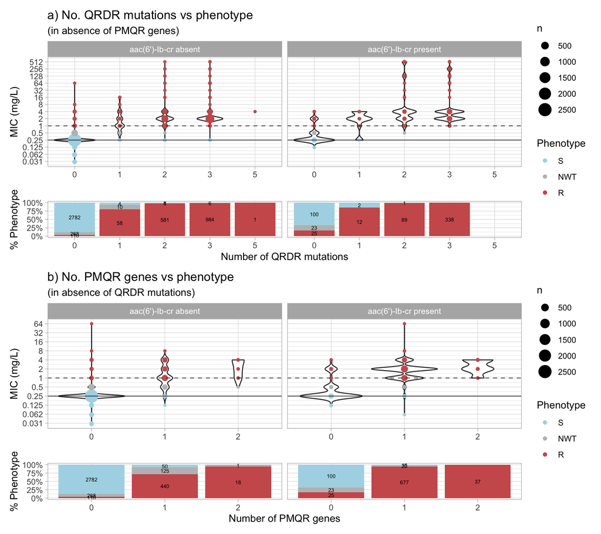

```r
QRDR_MIC_noGenes / QRDR_pheno_noGenes / qnr_MIC_noGenes / qnr_pheno_noGenes + plot_layout(heights=c(3,1, 3, 1))
```

```r
ggsave("figs/Fig2_numQnr_numPMQR_MIC_pheno.pdf", width=6, height=10)
ggsave("figs/Fig2_numQnr_numPMQR_MIC_pheno.png", width=6, height=10)
```

# Fig S9 - number of qnr vs DD, facet aac6 yes/no (no QRDR)

```r
# DD distribution for # qnr, in absence of genes
qnr_DD_noGenes <- cipro_antibiogram %>%
    filter(QRDR_mutations==0) %>%
    filter(Laboratory.Typing.Method=="Disk diffusion") %>%
    mutate(aac6_label=if_else(aac6==0, "aac(6ʹ)-Ib-cr absent", "aac(6ʹ)-Ib-cr present")) %>%
    ggplot(aes(x=factor(acquired_genes), y=as.numeric(Measurement))) +
    geom_violin() +
    geom_count(aes(colour = SRnwt)) +
    geom_hline(aes(yintercept = 21.0), linetype = 1, alpha = 0.6, color = "black") +
    geom_hline(aes(yintercept = 25.0), linetype = 2, alpha = 0.6, color = "black") +
    facet_wrap(vars(aac6_label)) +
      scale_color_manual(values = res_colours) +
    theme_light() +
    labs(y="Disk diffusion\n zone diameter (mm)", x="", col="Phenotype",
         title="No. PMQR genes vs phenotype",
         subtitle="(in absence of QRDR mutations)")


qnr_DDpheno_noGenes <- cipro_antibiogram %>%
    filter(QRDR_mutations==0) %>%
    filter(Laboratory.Typing.Method=="Disk diffusion") %>%
    mutate(aac6_label=if_else(aac6==0, "aac(6ʹ)-Ib-cr absent", "aac(6ʹ)-Ib-cr present")) %>%
    ggplot(aes(x=factor(acquired_genes), fill=SRnwt)) +
    geom_bar(stat='count', position='fill') +
    facet_wrap(vars(aac6_label)) +
      scale_fill_manual(values = res_colours) +
    scale_y_continuous(labels=scales::percent_format()) +
    geom_text(aes(label=..count..), stat="count", position=position_fill(vjust = .5), size=2) +
    theme_light() +
    labs(y="% Phenotype", x="Number of PMQR genes") +
    theme(legend.position="none", strip.background = element_blank(), strip.text = element_blank())
```

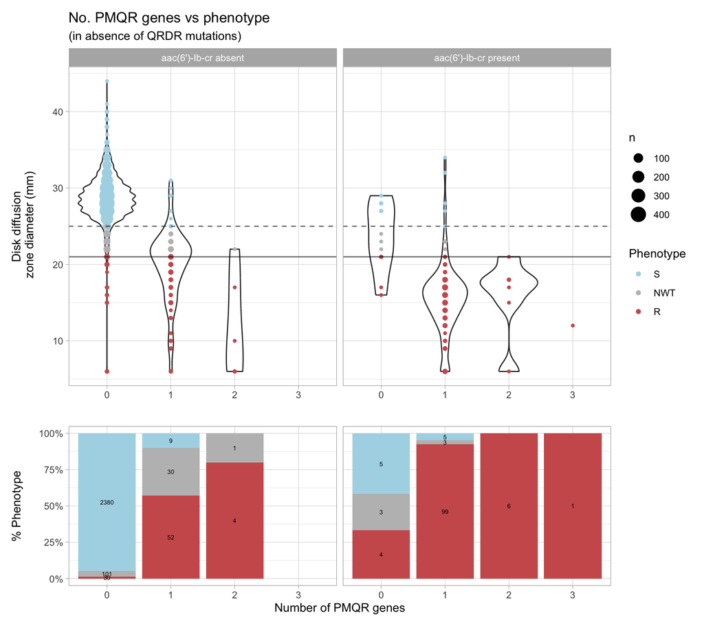

```r
qnr_DD_noGenes / qnr_DDpheno_noGenes + plot_layout(heights=c(2,1))
```

```r
ggsave("figs/FigS9_numQnr_DD_pheno.pdf", width=6, height=4)
ggsave("figs/FigS9_numQnr_DD_pheno.png", width=6, height=4)
```

# Fig3 panel b - aac6, QRDR mutations, qnr with DD data

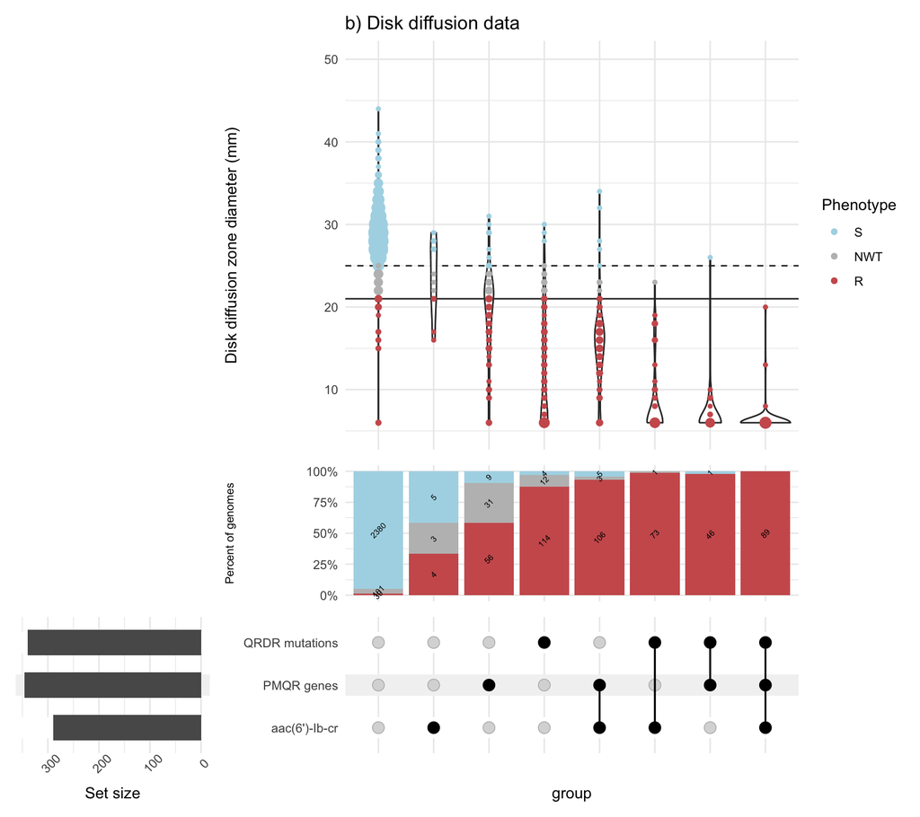

```r
upset_aac6_simple_DD <- cipro_antibiogram %>%
  filter(Laboratory.Typing.Method == "Disk diffusion") %>%
  upset(
      intersect=c("aac6","acquired_genes", "QRDR_mutations"),# counts are converted to binary
      sort_sets=FALSE,
      set_sizes=(
        upset_set_size()
        + theme(axis.text.x=element_text(angle=45))),
      intersections=list(
        'Outside of known sets',
        "aac6",
        "acquired_genes",
        'QRDR_mutations',
        c("aac6","acquired_genes"),
        c("aac6","QRDR_mutations"),
        c("acquired_genes","QRDR_mutations"),
        c("aac6","acquired_genes","QRDR_mutations")),
            sort_intersections=FALSE,
        labeller=ggplot2::as_labeller(c(
        'QRDR_mutations'='QRDR mutations',
        'acquired_genes'='PMQR genes',
        'aac6'="aac(6ʹ)-Ib-cr")),
      base_annotations=list( # add stacked barplot showing S/nonS
        'Percent of genomes'=list(
        aes=aes(x=intersection, fill=SRnwt),
          geom=list(
            geom_bar(stat='count', position='fill'),
             scale_fill_manual(values = res_colours),
            scale_y_continuous(labels=scales::percent_format()),
            theme(legend.position = "none", axis.title=element_text(size=8)),
            geom_text(aes(label=..count..), stat="count", position=position_fill(vjust = .5), angle = 45, size=2))
        )
      ),
      annotations= list( # add violin plot with disk diffusion data
        'Disk diffusion zone diameter (mm)'=(
            ggplot(mapping=aes(y=as.numeric(Measurement))) +
              geom_hline(aes(yintercept = 21.0), linetype = 1, alpha = 0.6, color = "black") +
              geom_hline(aes(yintercept = 25.0), linetype = 2, alpha = 0.6, color = "black") +
              geom_violin()+
              geom_count(aes(colour = SRnwt))+
              scale_color_manual(values = res_colours)+
              guides(size = "none") +
              labs(linetype = "CLSI/EUCAST", colour = "Phenotype") +
              ggtitle("b) Disk diffusion data") +
              ylim(5,50)
        )
      )
    ) + patchwork::plot_layout(heights=c(3,1,1)) # relative heights of plotting areas

upset_aac6_simple_DD
```

# Fig3 panel a - aac6, QRDR mutations, qnr with MIC data

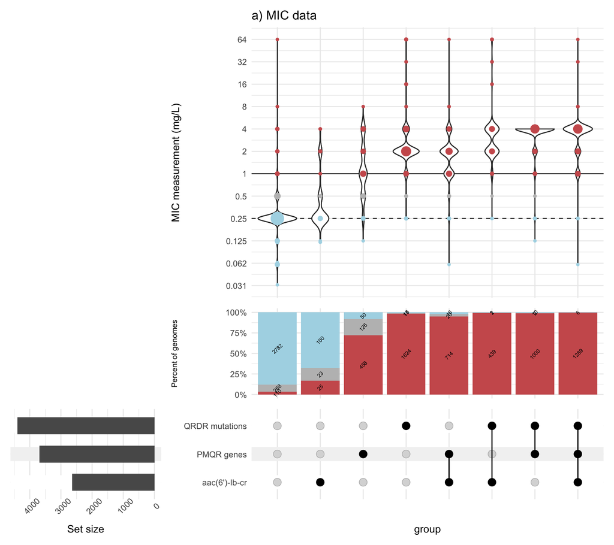

```r
upset_aac6_simple_MIC <- cipro_antibiogram %>%
  filter(grepl('MIC.*$', Laboratory.Typing.Method)) %>%
  upset(
      intersect=c("aac6","acquired_genes", "QRDR_mutations"),# counts are converted to binary
      sort_sets=FALSE,
      set_sizes=(
        upset_set_size()
        + theme(axis.text.x=element_text(angle=45))),
      intersections=list(
        'Outside of known sets',
        "aac6",
        "acquired_genes",
        'QRDR_mutations',
        c("aac6","acquired_genes"),
        c("aac6","QRDR_mutations"),
        c("acquired_genes","QRDR_mutations"),
        c("aac6","acquired_genes","QRDR_mutations")),
        labeller=ggplot2::as_labeller(c(
        'QRDR_mutations'='QRDR mutations',
        'acquired_genes'='PMQR genes',
        'aac6'="aac(6ʹ)-Ib-cr")),
      sort_intersections=FALSE,
      base_annotations=list( # add stacked barplot showing S/nonS
        'Percent of genomes'=list(
        aes=aes(x=intersection, fill=SRnwt),
          geom=list(
            geom_bar(stat='count', position='fill'),
             scale_fill_manual(values = res_colours) ,
            scale_y_continuous(labels=scales::percent_format()),
            theme(legend.position = "none", axis.title=element_text(size=8)),
            geom_text(aes(label=..count..), stat="count", position=position_fill(vjust = .5), angle = 45, size=2))
        )
      ),
      annotations= list( # add violin plot with MIC data
        'MIC measurement (mg/L)'=(
            ggplot(mapping=aes(y=as.numeric(Measurement))) +
              geom_hline(aes(yintercept = 1), linetype = 1, alpha = 0.6, color = "black")  +
              geom_hline(aes(yintercept = 0.25), linetype = 2, alpha = 0.6, color = "black")  +
              geom_violin()+
              geom_count(aes(colour = SRnwt))+
               scale_color_manual(values = res_colours)+
              scale_y_continuous(trans = log2_trans(), breaks = 2^(-5:6), labels = function(x) round(as.numeric(x), digits = 3), limits=c(2^-5,2^6)) +
              labs(colour = "Phenotype") +
              theme(legend.position="none") +
              ggtitle("a) MIC data")
        )

      )
    ) + patchwork::plot_layout(heights=c(3,1,1)) # relative heights of plotting areas

upset_aac6_simple_MIC
```

## Fig3: aac6, QRDR mutations, qnr with MIC & DD data

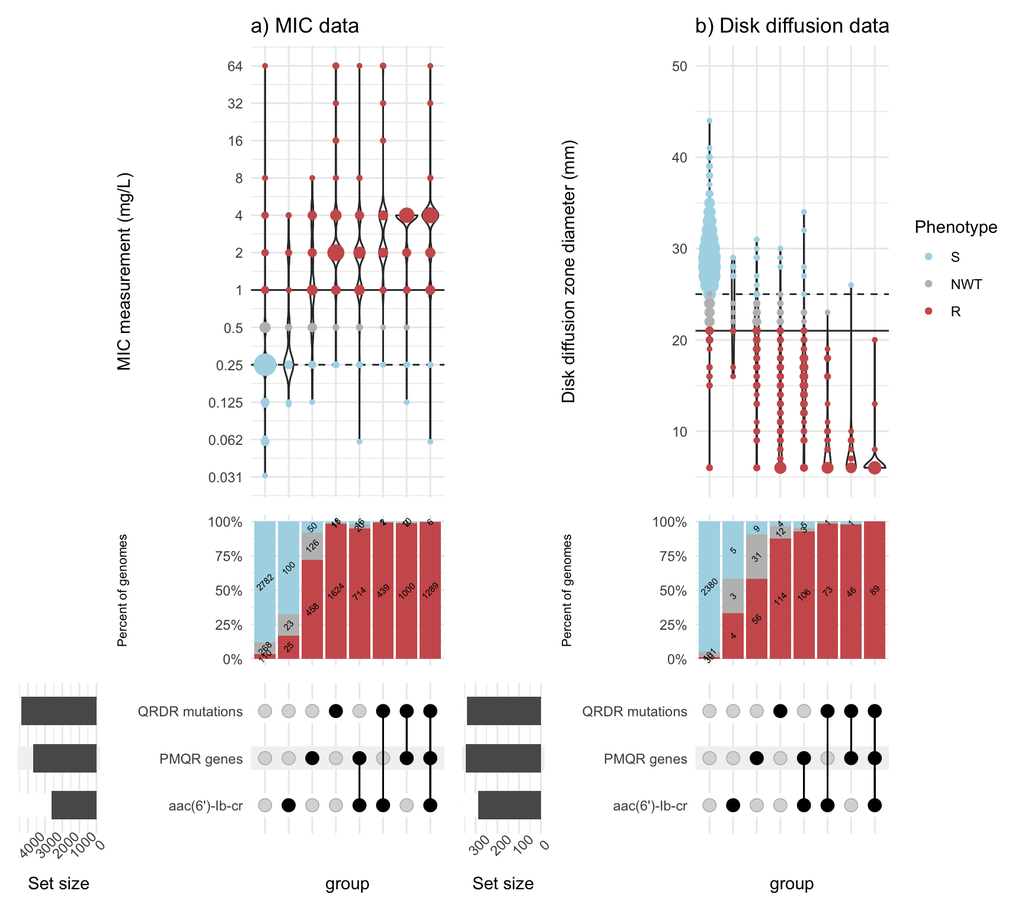

```r
upset_aac6_simple_MIC | upset_aac6_simple_DD
```

```r
ggsave("figs/Fig3_simple_comb_MIC_DD.pdf", width=12, height=6)
ggsave("figs/Fig3_simple_comb_MIC_DD.png", width=12, height=6)
```

# numbers for text - paragraph 6, effect of aac6 gene, in absence of QRDR and other acquired

```r
# MIC
aac_MIC_nullBG_dat <- cipro_antibiogram %>%
  filter(Laboratory.Typing.Method !="Disk diffusion") %>%
    filter(acquired_genes==0 & QRDR_mutations==0) %>%
  select(Measurement, Resistance.phenotype, resistant, nonWT_binary, aac6)

# MIC vs presence/absence of qnr
wilcox.test(log2(as.numeric(Measurement)) ~ aac6, data=aac_MIC_nullBG_dat)
```

```
##
##  Wilcoxon rank sum test with continuity correction
##
## data:  log2(as.numeric(Measurement)) by aac6
## W = 175371, p-value = 2.52e-13
## alternative hypothesis: true location shift is not equal to 0
```

```r
summary(lm(log2(as.numeric(Measurement)) ~ aac6, data=aac_MIC_nullBG_dat))
```

```
##
## Call:
## lm(formula = log2(as.numeric(Measurement)) ~ aac6, data = aac_MIC_nullBG_dat)
##
## Residuals:
##     Min      1Q  Median      3Q     Max
## -3.1003 -0.0414 -0.0414 -0.0414  7.9586
##
## Coefficients:
##             Estimate Std. Error  t value Pr(>|t|)
## (Intercept) -1.95856    0.01525 -128.421   <2e-16 ***
## aac6         0.59966    0.07210    8.317   <2e-16 ***
## ---
## Signif. codes:  0 '***' 0.001 '**' 0.01 '*' 0.05 '.' 0.1 ' ' 1
##
## Residual standard error: 0.8573 on 3306 degrees of freedom
## Multiple R-squared:  0.02049,    Adjusted R-squared:  0.0202
## F-statistic: 69.17 on 1 and 3306 DF,  p-value: < 2.2e-16
```

```r
summary(as.numeric(aac_MIC_nullBG_dat$Measurement)[aac_MIC_nullBG_dat$aac6==1])
```

```
##    Min. 1st Qu.  Median    Mean 3rd Qu.    Max.
##  0.1200  0.2500  0.2500  0.6021  0.5000  4.0000
```

```r
summary(as.numeric(aac_MIC_nullBG_dat$Measurement)[aac_MIC_nullBG_dat$aac6==0])
```

```
##    Min. 1st Qu.  Median    Mean 3rd Qu.    Max.
##  0.0300  0.2500  0.2500  0.3421  0.2500 64.0000
```

```r
aac_MIC_nullBG_dat %>% group_by(aac6) %>% summarise(S=mean(Resistance.phenotype=="S"), I=mean(Resistance.phenotype=="I"), R=mean(Resistance.phenotype=="R"))
```

| aac6 | S | I | R |
| --- | --- | --- | --- |
| 0 | 0.8803797 | 0.08481013 | 0.03481013 |
| 1 | 0.6756757 | 0.15540541 | 0.16891892 |

```r
# DD
aac_DD_nullBG_dat <- cipro_antibiogram %>%
    filter(acquired_genes==0 & QRDR_mutations==0) %>%
    filter(Laboratory.Typing.Method=="Disk diffusion") %>%
  select(Measurement, Resistance.phenotype, resistant, nonWT_binary, aac6)

wilcox.test(as.numeric(Measurement) ~ aac6, data=aac_DD_nullBG_dat)
```

```
##
##  Wilcoxon rank sum test with continuity correction
##
## data:  as.numeric(Measurement) by aac6
## W = 25156, p-value = 5.356e-05
## alternative hypothesis: true location shift is not equal to 0
```

```r
summary(lm(as.numeric(Measurement) ~ aac6, data=aac_DD_nullBG_dat))
```

```
##
## Call:
## lm(formula = as.numeric(Measurement) ~ aac6, data = aac_DD_nullBG_dat)
##
## Residuals:
##      Min       1Q   Median       3Q      Max
## -22.6659  -1.6659   0.3341   1.3341  15.3341
##
## Coefficients:
##             Estimate Std. Error t value Pr(>|t|)
## (Intercept) 28.66587    0.05766 497.182  < 2e-16 ***
## aac6        -5.08254    0.83602  -6.079 1.39e-09 ***
## ---
## Signif. codes:  0 '***' 0.001 '**' 0.01 '*' 0.05 '.' 0.1 ' ' 1
##
## Residual standard error: 2.889 on 2521 degrees of freedom
## Multiple R-squared:  0.01445,    Adjusted R-squared:  0.01406
## F-statistic: 36.96 on 1 and 2521 DF,  p-value: 1.389e-09
```

```r
summary(as.numeric(aac_DD_nullBG_dat$Measurement)[aac_DD_nullBG_dat$aac6==1])
```

```
##    Min. 1st Qu.  Median    Mean 3rd Qu.    Max.
##   16.00   21.00   23.50   23.58   27.25   29.00
```

```r
summary(as.numeric(aac_DD_nullBG_dat$Measurement)[aac_DD_nullBG_dat$aac6==0])
```

```
##    Min. 1st Qu.  Median    Mean 3rd Qu.    Max.
##    6.00   27.00   29.00   28.67   30.00   44.00
```

```r
aac_DD_nullBG_dat %>% group_by(aac6) %>% summarise(S=mean(Resistance.phenotype=="S"), I=mean(Resistance.phenotype=="I"), R=mean(Resistance.phenotype=="R"))
```

| aac6 | S | I | R |
| --- | --- | --- | --- |
| 0 | 0.9478295 | 0.04022302 | 0.01194743 |
| 1 | 0.4166667 | 0.25000000 | 0.33333333 |

```r
# all genomes with no acquired genes (MIC/DD)
qnr_noGenes_dat <- cipro_antibiogram %>%
    filter(acquired_genes==0 & QRDR_mutations==0) %>%
  select(Measurement, Resistance.phenotype, resistant, nonWT_binary, aac6)

dim(qnr_noGenes_dat)
```

```
## [1] 5831    5
```

```r
# NOT USED
# Test figure for upset plot to include all determinants

# all determinants
qrdr_genes <- c(
  "aac6",
  "ParC-84",
  "ParC-80",
  "GyrA-87",
  "GyrA-83",
  "qnrA1",
  "qnrB17",
  "qnrB19",
  "qnrB4",
  "qnrB6",
  "qnrS1"
)


upset_QRDR_prop <- cipro_antibiogram %>%
  upset(
    intersect = qrdr_genes,

    sort_intersections = "descending",

    min_size = 10,

    width_ratio = 0.15,
    height_ratio = 1.5,

    set_sizes = (
      upset_set_size() +
        theme(
          axis.text.x = element_text(
            angle = 90,
            hjust = 0.5,
            vjust = 0.5
          )
        )
    ),

    base_annotations = list(
      'Percent of genomes' = list(
        aes = aes(x = intersection, fill = SRnwt),
        geom = list(
          geom_bar(stat = "count", position = "fill"),
          scale_fill_manual(values = res_colours),
          scale_y_continuous(labels = scales::percent_format()),
          geom_text(
            aes(label = after_stat(count)),
            stat = "count",
            position = position_fill(vjust = .5),
            angle = 45,
            size = 2
          )
        )
      )
    )
  )
upset_QRDR_prop
#ggsave("figs/FigSX_allcombo.png", width=10, height=6)
```